# **Dogs-vs-Cats Image Classification**

```
load model
```

```
load image
```

```
Confusion matrix, without normalization
[[709 291]
 [ 59 941]]
```

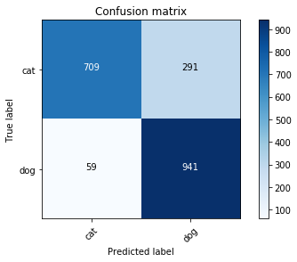

```
Testaccuracy: 0.825
```

```python
#load model
print('load model')
modelPath="Dogs-vs-Cats/trainResults/"
modelName='model_cnn_rgb_reg_aug'
model = load_model(modelPath+modelName+'.h5')

#connect to image directory
print('load image')
imagePath="Dogs-vs-Cats/testDataSet/"
files=os.listdir(imagePath)

#load means
with open("Dogs-vs-Cats/means.pickle", "rb") as input_file:
    means = pickle.load(input_file)

#classification parameter
dim=model.input.shape.as_list()
classes={'cat':0,'dog':1}

actualClasses=[]
predictedClasses=[]
diff=[]

#iterate image files
for file in tqdm(files):
    #load image
    img = imageio.imread(imagePath+file,as_gray=False)
    label = classes[file.split('(')[0]]

    #scale image
    img = cv2.resize(img, dsize=(dim[1],dim[2]), interpolation=cv2.INTER_CUBIC)
    img = np.reshape(img,[1,dim[1],dim[2],3])
    prediction = model.predict(img)

    actualClasses.append(label)
    predictedClasses.append(np.argmax(prediction))

#confusion matrix
conf=confusion_matrix(actualClasses, predictedClasses)

plt.figure()
plot_confusion_matrix(conf, classes=list(classes.keys()), title='Confusion matrix')
plt.savefig(modelPath+'_confMat_'+modelName)
plt.show()

#calculate test accuracy
diff=[1 if x[0]!=x[1] else 0 for x in zip(actualClasses,predictedClasses)]
print('Testaccuracy: {0}'.format(1-sum(diff)/len(diff)))
```

**Resnet with RGB Images and Data Augmentation:**

```
WARNING:tensorflow:sample_weight modes were coerced from
  ...
    to
  ['...']
Train for 125 steps, validate on 6900 samples
Trainingduration: 0:12:33.855632
```

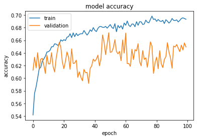

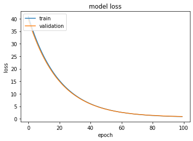

```python
#load data

dataDirectory="Dogs-vs-Cats/dataSet/"
output="Dogs-vs-Cats/trainResults/"
modelName='model_cnn_rgb_resnet_aug'

#manage directory
if not os.path.exists(output):
    os.makedirs(output)

#parameter
batchSize=128
epochs=100
validationSplit=0.30

features = dataDirectory+'data.npy'
X = np.load(features)

labels = dataDirectory+'labels.npy'
y = np.load(labels)

#%% Callbacks
callbacks=[]
callbacks.append(EarlyStopping(monitor='val_loss',patience=15,verbose=0, mode='auto'))
callbacks.append(ModelCheckpoint(output+modelName+'_check_.h5', save_best_only=True, monitor='val_loss', mode='min'))

seed = 7

#Split into train/test sets
X_train, X_val, y_train, y_val = train_test_split(X, y, test_size=validationSplit,random_state=seed,stratify=y)
steps_per_epoch=len(X_train)//batchSize

model=getResnet(np.shape(X[0]),2)

#compile model

opt=optimizers.SGD(lr=0.001,momentum=0.9)
model.compile(optimizer=opt , loss='categorical_crossentropy', metrics=['accuracy'])

#data augmentation
aug = ImageDataGenerator(
        rotation_range=10,  # rotate in degrees
        zoom_range = 0.1, # zoom
        width_shift_range=0.2,  # shift images horizontally
        height_shift_range=0.2,  # shift images vertically
        horizontal_flip=True,  # flip images
        vertical_flip=False)  # flip images

#Train Model
t = time.time()
hist = model.fit_generator(aug.flow(X_train, y_train, batch_size=batchSize), validation_data=(X_val, y_val), steps_per_epoch=steps_per_epoch, epochs=epochs, callbacks=callbacks, verbose=1)

elapsed = time.time() - t
print('Trainingduration: '+str(datetime.timedelta(seconds=elapsed)))

#save model
model.save(output+modelName+'.h5')

#generate and save plots
# plot history for accuracy
plt.figure()
plt.ioff()
plt.plot(hist.history['accuracy'])
plt.plot(hist.history['val_accuracy'])
plt.title('model accuracy')
plt.ylabel('accuracy')
plt.xlabel('epoch')
plt.legend(['train', 'validation'], loc='upper left')
plt.savefig(output+'_accuracy_'+modelName)

# plot history for loss
plt.figure()
plt.ioff()
plt.plot(hist.history['loss'])
plt.plot(hist.history['val_loss'])
plt.title('model loss')
plt.ylabel('loss')
plt.xlabel('epoch')
plt.legend(['train', 'validation'], loc='upper left')
plt.savefig(output+'_loss_'+modelName)

#save detail information
with open(output+modelName+".txt","w+") as f:

    f.write('Trainparameter:\n')
    f.write('ValidationSplit: {0}\n'.format(validationSplit))
    f.write('Batchsize: {0}\n'.format(batchSize))
    f.write('Epochs: {0}\n'.format(epochs))
    f.write('Steps per epoch: {0}\n'.format(steps_per_epoch))
    f.write('Inputdimension:\n'+str(np.shape(X_train[0])))
    f.write('\n')
    f.write('Results:\n')
    f.write('Trainaccuracy: {0}\n'.format(hist.history['accuracy'][-1]*100))
    f.write('Validationaccuracy: {0}\n'.format(hist.history['val_accuracy'][-1]*100))
    f.write('Best Validation: {0}\n'.format(np.max(hist.history['val_accuracy'])*100))
    f.write('\n')
    f.write('Modelarchitecture:\n')
    with redirect_stdout(f):
        model.summary()
```

```
load model
```

```
load image
```

```
Confusion matrix, without normalization
[[408 592]
 [102 898]]
```

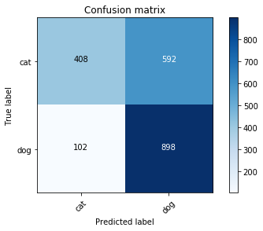

```
Testaccuracy: 0.653
```

```python
#load model
print('load model')
modelPath="Dogs-vs-Cats/trainResults/"
modelName='model_cnn_rgb_resnet_aug'
model = load_model(modelPath+modelName+'.h5')

#connect to image directory
print('load image')
imagePath="Dogs-vs-Cats/testDataSet/"
files=os.listdir(imagePath)

#load means
with open("Dogs-vs-Cats/means.pickle", "rb") as input_file:
    means = pickle.load(input_file)

#classification parameter
dim=model.input.shape.as_list()
classes={'cat':0,'dog':1}

actualClasses=[]
predictedClasses=[]
diff=[]

#iterate image files
for file in tqdm(files):
    #load image
    img = imageio.imread(imagePath+file,as_gray=False)
    label = classes[file.split('(')[0]]

    #scale image
    img = cv2.resize(img, dsize=(dim[1],dim[2]), interpolation=cv2.INTER_CUBIC)
    img = np.reshape(img,[1,dim[1],dim[2],3])
    prediction = model.predict(img)

    actualClasses.append(label)
    predictedClasses.append(np.argmax(prediction))

#confusion matrix
conf=confusion_matrix(actualClasses, predictedClasses)

plt.figure()
plot_confusion_matrix(conf, classes=list(classes.keys()), title='Confusion matrix')
plt.savefig(modelPath+'_confMat_'+modelName)
plt.show()

#calculate test accuracy
diff=[1 if x[0]!=x[1] else 0 for x in zip(actualClasses,predictedClasses)]
print('Testaccuracy: {0}'.format(1-sum(diff)/len(diff)))
```

**VGG16 with RGB Images and Data Augmentation:**

```
WARNING:tensorflow:sample_weight modes were coerced from
  ...
    to
  ['...']
Train for 125 steps, validate on 6900 samples
Trainingduration: 0:11:25.672750
```

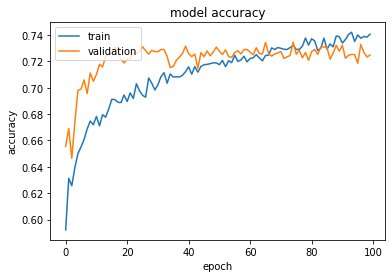

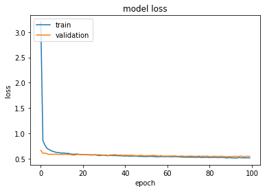

```python
#load data

dataDirectory="Dogs-vs-Cats/dataSet/"
output="Dogs-vs-Cats/trainResults/"
modelName='model_cnn_rgb_vgg_aug'

#manage directory
if not os.path.exists(output):
    os.makedirs(output)

#parameter
batchSize=128
epochs=100
validationSplit=0.30

features = dataDirectory+'data.npy'
X = np.load(features)

labels = dataDirectory+'labels.npy'
y = np.load(labels)

#%% Callbacks
callbacks=[]
callbacks.append(EarlyStopping(monitor='val_loss',patience=15,verbose=0, mode='auto'))
callbacks.append(ModelCheckpoint(output+modelName+'_check_.h5', save_best_only=True, monitor='val_loss', mode='min'))

seed = 7

#Split into train/test sets
X_train, X_val, y_train, y_val = train_test_split(X, y, test_size=validationSplit,random_state=seed,stratify=y)
steps_per_epoch=len(X_train)//batchSize

model=vgg16(np.shape(X[0]),2)

#compile model

opt=optimizers.SGD(lr=0.001,momentum=0.9)
model.compile(optimizer=opt , loss='categorical_crossentropy', metrics=['accuracy'])

#data augmentation
aug = ImageDataGenerator(
        rotation_range=10,  # rotate in degrees
        zoom_range = 0.1, # zoom
        width_shift_range=0.2,  # shift images horizontally
        height_shift_range=0.2,  # shift images vertically
        horizontal_flip=True,  # flip images
        vertical_flip=False)  # flip images

#Train Model
t = time.time()
hist = model.fit_generator(aug.flow(X_train, y_train, batch_size=batchSize), validation_data=(X_val, y_val), steps_per_epoch=steps_per_epoch, epochs=epochs, callbacks=callbacks, verbose=1)

elapsed = time.time() - t
print('Trainingduration: '+str(datetime.timedelta(seconds=elapsed)))

#save model
model.save(output+modelName+'.h5')

#generate and save plots
# plot history for accuracy
plt.figure()
plt.ioff()
plt.plot(hist.history['accuracy'])
plt.plot(hist.history['val_accuracy'])
plt.title('model accuracy')
plt.ylabel('accuracy')
plt.xlabel('epoch')
plt.legend(['train', 'validation'], loc='upper left')
plt.savefig(output+'_accuracy_'+modelName)

# plot history for loss
plt.figure()
plt.ioff()
plt.plot(hist.history['loss'])
plt.plot(hist.history['val_loss'])
plt.title('model loss')
plt.ylabel('loss')
plt.xlabel('epoch')
plt.legend(['train', 'validation'], loc='upper left')
plt.savefig(output+'_loss_'+modelName)

#save detail information
with open(output+modelName+".txt","w+") as f:

    f.write('Trainparameter:\n')
    f.write('ValidationSplit: {0}\n'.format(validationSplit))
    f.write('Batchsize: {0}\n'.format(batchSize))
    f.write('Epochs: {0}\n'.format(epochs))
    f.write('Steps per epoch: {0}\n'.format(steps_per_epoch))
    f.write('Inputdimension:\n'+str(np.shape(X_train[0])))
    f.write('\n')
    f.write('Results:\n')
    f.write('Trainaccuracy: {0}\n'.format(hist.history['accuracy'][-1]*100))
    f.write('Validationaccuracy: {0}\n'.format(hist.history['val_accuracy'][-1]*100))
    f.write('Best Validation: {0}\n'.format(np.max(hist.history['val_accuracy'])*100))
    f.write('\n')
    f.write('Modelarchitecture:\n')
    with redirect_stdout(f):
        model.summary()
```

```
load model
```

```
load image
```

```
Confusion matrix, without normalization
[[833 167]
 [377 623]]
```

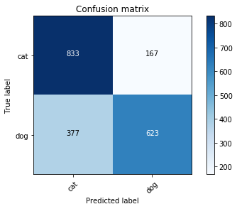

```
Testaccuracy: 0.728
```

```python
#load model
print('load model')
modelPath="Dogs-vs-Cats/trainResults/"
modelName='model_cnn_rgb_vgg_aug'
model = load_model(modelPath+modelName+'.h5')

#connect to image directory
print('load image')
imagePath="Dogs-vs-Cats/testDataSet/"
files=os.listdir(imagePath)

#load means
with open("Dogs-vs-Cats/means.pickle", "rb") as input_file:
    means = pickle.load(input_file)

#classification parameter
dim=model.input.shape.as_list()
classes={'cat':0,'dog':1}

actualClasses=[]
predictedClasses=[]
diff=[]

#iterate image files
for file in tqdm(files):
    #load image
    img = imageio.imread(imagePath+file,as_gray=False)
    label = classes[file.split('(')[0]]

    #scale image
    img = cv2.resize(img, dsize=(dim[1],dim[2]), interpolation=cv2.INTER_CUBIC)
    img = np.reshape(img,[1,dim[1],dim[2],3])
    prediction = model.predict(img)

    actualClasses.append(label)
    predictedClasses.append(np.argmax(prediction))

#confusion matrix
conf=confusion_matrix(actualClasses, predictedClasses)

plt.figure()
plot_confusion_matrix(conf, classes=list(classes.keys()), title='Confusion matrix')
plt.savefig(modelPath+'_confMat_'+modelName)
plt.show()

#calculate test accuracy
diff=[1 if x[0]!=x[1] else 0 for x in zip(actualClasses,predictedClasses)]
print('Testaccuracy: {0}'.format(1-sum(diff)/len(diff)))
```

**VGG16 with RGB Images, Data Augmentation and Fine Tuning:**

```
WARNING:tensorflow:sample_weight modes were coerced from
  ...
    to
  ['...']
Train for 125 steps, validate on 6900 samples
Trainingduration: 0:12:40.205689
```

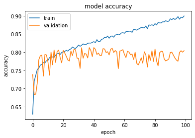

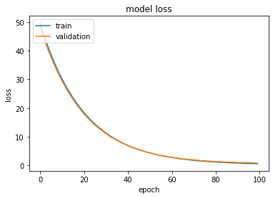

```python
#load data

dataDirectory="Dogs-vs-Cats/dataSet/"
output="Dogs-vs-Cats/trainResults/"
modelName='model_cnn_rgb_vgg2_aug'

#manage directory
if not os.path.exists(output):
    os.makedirs(output)

#parameter
batchSize=128
epochs=100
validationSplit=0.30

features = dataDirectory+'data.npy'
X = np.load(features)

labels = dataDirectory+'labels.npy'
y = np.load(labels)

#%% Callbacks
callbacks=[]
callbacks.append(EarlyStopping(monitor='val_loss',patience=15,verbose=0, mode='auto'))
callbacks.append(ModelCheckpoint(output+modelName+'_check_.h5', save_best_only=True, monitor='val_loss', mode='min'))

seed = 7

#Split into train/test sets
X_train, X_val, y_train, y_val = train_test_split(X, y, test_size=validationSplit,random_state=seed,stratify=y)
steps_per_epoch=len(X_train)//batchSize

model=vgg16v2(np.shape(X[0]),2)

#compile model

opt=optimizers.SGD(lr=0.001,momentum=0.9)
model.compile(optimizer=opt , loss='categorical_crossentropy', metrics=['accuracy'])

#data augmentation
aug = ImageDataGenerator(
        rotation_range=10,  # rotate in degrees
        zoom_range = 0.1, # zoom
        width_shift_range=0.2,  # shift images horizontally
        height_shift_range=0.2,  # shift images vertically
        horizontal_flip=True,  # flip images
        vertical_flip=False)  # flip images

#Train Model
t = time.time()
hist = model.fit_generator(aug.flow(X_train, y_train, batch_size=batchSize), validation_data=(X_val, y_val), steps_per_epoch=steps_per_epoch, epochs=epochs, callbacks=callbacks, verbose=1)

elapsed = time.time() - t
print('Trainingduration: '+str(datetime.timedelta(seconds=elapsed)))

#save model
model.save(output+modelName+'.h5')

#generate and save plots
# plot history for accuracy
plt.figure()
plt.ioff()
plt.plot(hist.history['accuracy'])
plt.plot(hist.history['val_accuracy'])
plt.title('model accuracy')
plt.ylabel('accuracy')
plt.xlabel('epoch')
plt.legend(['train', 'validation'], loc='upper left')
plt.savefig(output+'_accuracy_'+modelName)

# plot history for loss
plt.figure()
plt.ioff()
plt.plot(hist.history['loss'])
plt.plot(hist.history['val_loss'])
plt.title('model loss')
plt.ylabel('loss')
plt.xlabel('epoch')
plt.legend(['train', 'validation'], loc='upper left')
plt.savefig(output+'_loss_'+modelName)

#save detail information
with open(output+modelName+".txt","w+") as f:

    f.write('Trainparameter:\n')
    f.write('ValidationSplit: {0}\n'.format(validationSplit))
    f.write('Batchsize: {0}\n'.format(batchSize))
    f.write('Epochs: {0}\n'.format(epochs))
    f.write('Steps per epoch: {0}\n'.format(steps_per_epoch))
    f.write('Inputdimension:\n'+str(np.shape(X_train[0])))
    f.write('\n')
    f.write('Results:\n')
    f.write('Trainaccuracy: {0}\n'.format(hist.history['accuracy'][-1]*100))
    f.write('Validationaccuracy: {0}\n'.format(hist.history['val_accuracy'][-1]*100))
    f.write('Best Validation: {0}\n'.format(np.max(hist.history['val_accuracy'])*100))
    f.write('\n')
    f.write('Modelarchitecture:\n')
    with redirect_stdout(f):
        model.summary()
```

```
load model
```

```
load image
```

```
Confusion matrix, without normalization
[[762 238]
 [149 851]]
```

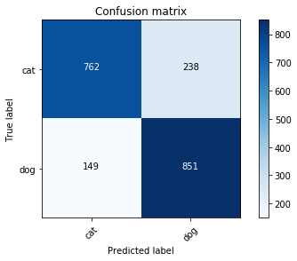

```
Testaccuracy: 0.8065
```

```python
#load model
print('load model')
modelPath="Dogs-vs-Cats/trainResults/"
modelName='model_cnn_rgb_vgg2_aug'
model = load_model(modelPath+modelName+'.h5')

#connect to image directory
print('load image')
imagePath="Dogs-vs-Cats/testDataSet/"
files=os.listdir(imagePath)

#load means
with open("Dogs-vs-Cats/means.pickle", "rb") as input_file:
    means = pickle.load(input_file)

#classification parameter
dim=model.input.shape.as_list()
classes={'cat':0,'dog':1}

actualClasses=[]
predictedClasses=[]
diff=[]

#iterate image files
for file in tqdm(files):
    #load image
    img = imageio.imread(imagePath+file,as_gray=False)
    label = classes[file.split('(')[0]]

    #scale image
    img = cv2.resize(img, dsize=(dim[1],dim[2]), interpolation=cv2.INTER_CUBIC)
    img = np.reshape(img,[1,dim[1],dim[2],3])
    prediction = model.predict(img)

    actualClasses.append(label)
    predictedClasses.append(np.argmax(prediction))

#confusion matrix
conf=confusion_matrix(actualClasses, predictedClasses)

plt.figure()
plot_confusion_matrix(conf, classes=list(classes.keys()), title='Confusion matrix')
plt.savefig(modelPath+'_confMat_'+modelName)
plt.show()

#calculate test accuracy
diff=[1 if x[0]!=x[1] else 0 for x in zip(actualClasses,predictedClasses)]
print('Testaccuracy: {0}'.format(1-sum(diff)/len(diff)))
```

**CNN with RGB Images and Mean Substraction:**

```python
imagePath="Dogs-vs-Cats/images/"
dataPath="Dogs-vs-Cats/"
output=dataPath+'/dataSetMean/'
testDir=dataPath+'./testDataSetMean/'

#manage directory
if not os.path.exists(output):
    os.makedirs(output)

if not os.path.exists(testDir):
    os.makedirs(testDir)

classNames=os.listdir(imagePath)
classes={classNames[i]: i for i in range(len(classNames))}

#dataset parameter
data=[]
labels=[]
testSize=1000
size=np.minimum(minx,miny)

#create datasets
for className in tqdm(classNames):
  print('\n'+className+'\n')
  classFiles=os.listdir(imagePath+className)
  classFiles=[x for x in classFiles if x.endswith('.jpg')]
  for i in range(testSize):
    file=classFiles[i]
    try:
        src=imagePath+className+"/"+file
        dst=testDir+"/"+className+'('+str(i)+').jpg'
        shutil.copy(src,dst)
    except:
        print('Could not copy file:\n'+file)
  classFiles=classFiles[testSize:]
  for file in classFiles:
    try:
        img = imageio.imread(imagePath+className+"/"+file,as_gray=False)
        label = classes[className]

        #scale image
        img = cv2.resize(img, dsize=(size,size), interpolation=cv2.INTER_CUBIC)
        img=np.reshape(img,(size,size,3))
        img=meanSubstraction(img,means)
        data.append(img.astype('float32'))
        labels.append(label)
    except Exception as e:
        print(e)
        print('Failed to process file:\n'+imagePath+className+"/"+file)

#class balancing
limit=min(Counter(labels).values())

#create final dataset
labelsBalanced=[]
dataBalanced=[]
classes=np.unique(labels)
for c in classes:
    print('Class {0}'.format(c))
    idx = np.where(labels == c)
    idx = idx[0].tolist()
    np.random.shuffle(idx)
    for i in tqdm(range(0,limit)):
        labelsBalanced.append(c)
        dataBalanced.append(data[idx[i]])

del labels
del data

#one hot encoding for classlabels
from sklearn.preprocessing import LabelEncoder
from keras.utils import np_utils

lab = LabelEncoder()
encodedLabels = np_utils.to_categorical(lab.fit_transform(labelsBalanced))

#save dataset + labels
np.save(output+'data_m', dataBalanced)
np.save(output+'labels_m', encodedLabels)
```

```
cat
```

```
dog
```

```
Class 0
Class 1
```

```
Train on 16100 samples, validate on 6900 samples
Trainingduration: 0:02:23.916459
```

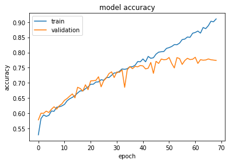

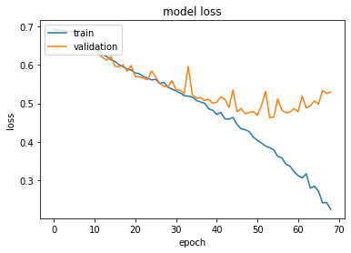

```python
#load data

dataDirectory="Dogs-vs-Cats/dataSetMean/"
output="Dogs-vs-Cats/trainResults/"
modelName='model_cnn_rgb_mean'

#manage directory
if not os.path.exists(output):
    os.makedirs(output)

#parameter
batchSize=128
epochs=1000
validationSplit=0.30

features = dataDirectory+'data_m.npy'
X = np.load(features)

labels = dataDirectory+'labels_m.npy'
y = np.load(labels)

#%% Callbacks
callbacks=[]
callbacks.append(EarlyStopping(monitor='val_loss',patience=15,verbose=0, mode='auto'))
callbacks.append(ModelCheckpoint(output+modelName+'_check_.h5', save_best_only=True, monitor='val_loss', mode='min'))

seed = 7

#Split into train/test sets
X_train, X_val, y_train, y_val = train_test_split(X, y, test_size=validationSplit,random_state=seed,stratify=y)
steps_per_epoch=len(X_train)//batchSize

model=getCNN(np.shape(X[0]),2)

#compile model

opt=optimizers.SGD(lr=0.001,momentum=0.9)
model.compile(optimizer=opt , loss='categorical_crossentropy', metrics=['accuracy'])

#Train Model
t = time.time()
hist = model.fit(X_train, y_train, batch_size=batchSize, epochs=epochs,validation_data=(X_val, y_val), callbacks=callbacks,verbose=1)

elapsed = time.time() - t
print('Trainingduration: '+str(datetime.timedelta(seconds=elapsed)))

#save model
model.save(output+modelName+'.h5')

#generate and save plots
# plot history for accuracy
plt.figure()
plt.ioff()
plt.plot(hist.history['accuracy'])
plt.plot(hist.history['val_accuracy'])
plt.title('model accuracy')
plt.ylabel('accuracy')
plt.xlabel('epoch')
plt.legend(['train', 'validation'], loc='upper left')
plt.savefig(output+'_accuracy_'+modelName)

# plot history for loss
plt.figure()
plt.ioff()
plt.plot(hist.history['loss'])
plt.plot(hist.history['val_loss'])
plt.title('model loss')
plt.ylabel('loss')
plt.xlabel('epoch')
plt.legend(['train', 'validation'], loc='upper left')
plt.savefig(output+'_loss_'+modelName)

#save detail information
with open(output+modelName+".txt","w+") as f:

    f.write('Trainparameter:\n')
    f.write('ValidationSplit: {0}\n'.format(validationSplit))
    f.write('Batchsize: {0}\n'.format(batchSize))
    f.write('Epochs: {0}\n'.format(epochs))
    f.write('Steps per epoch: {0}\n'.format(steps_per_epoch))
    f.write('Inputdimension:\n'+str(np.shape(X_train[0])))
    f.write('\n')
    f.write('Results:\n')
    f.write('Trainaccuracy: {0}\n'.format(hist.history['accuracy'][-1]*100))
    f.write('Validationaccuracy: {0}\n'.format(hist.history['val_accuracy'][-1]*100))
    f.write('Best Validation: {0}\n'.format(np.max(hist.history['val_accuracy'])*100))
    f.write('\n')
    f.write('Modelarchitecture:\n')
    with redirect_stdout(f):
        model.summary()
```

```
load model
```

```
load image
```

```
Confusion matrix, without normalization
[[766 234]
 [215 785]]
```

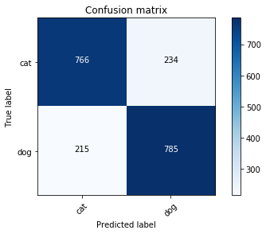

```
Testaccuracy: 0.7755
```

```python
#load model
print('load model')
modelPath="Dogs-vs-Cats/trainResults/"
modelName='model_cnn_rgb_mean'
model = load_model(modelPath+modelName+'.h5')

#connect to image directory
print('load image')
imagePath="Dogs-vs-Cats/testDataSetMean/"
files=os.listdir(imagePath)

#load means
with open("Dogs-vs-Cats/means.pickle", "rb") as input_file:
    means = pickle.load(input_file)

#classification parameter
dim=model.input.shape.as_list()
classes={'cat':0,'dog':1}

actualClasses=[]
predictedClasses=[]
diff=[]

#iterate image files
for file in tqdm(files):
    #load image
    img = imageio.imread(imagePath+file,as_gray=False)
    label = classes[file.split('(')[0]]

    #scale image
    img = cv2.resize(img, dsize=(dim[1],dim[2]), interpolation=cv2.INTER_CUBIC)
    img = meanSubstraction(img,means)
    img = np.reshape(img,[1,dim[1],dim[2],3])
    prediction = model.predict(img)

    actualClasses.append(label)
    predictedClasses.append(np.argmax(prediction))

#confusion matrix
conf=confusion_matrix(actualClasses, predictedClasses)

plt.figure()
plot_confusion_matrix(conf, classes=list(classes.keys()), title='Confusion matrix')
plt.savefig(modelPath+'_confMat_'+modelName)
plt.show()

#calculate test accuracy
diff=[1 if x[0]!=x[1] else 0 for x in zip(actualClasses,predictedClasses)]
print('Testaccuracy: {0}'.format(1-sum(diff)/len(diff)))
```

**CNN with RGB Images, Mean Substraction and Batch-Normalization/Dropout:**

```
Train on 16100 samples, validate on 6900 samples
Trainingduration: 0:01:07.690671
```

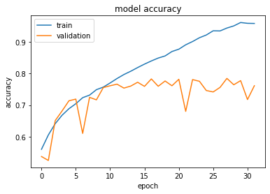

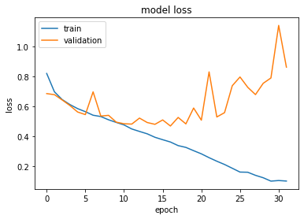

```python
#load data

dataDirectory="Dogs-vs-Cats/dataSetMean/"
output="Dogs-vs-Cats/trainResults/"
modelName='model_cnn_rgb_batchnorm_mean'

#manage directory
if not os.path.exists(output):
    os.makedirs(output)

#parameter
batchSize=128
epochs=1000
validationSplit=0.30

features = dataDirectory+'data_m.npy'
X = np.load(features)

labels = dataDirectory+'labels_m.npy'
y = np.load(labels)

#%% Callbacks
callbacks=[]
callbacks.append(EarlyStopping(monitor='val_loss',patience=15,verbose=0, mode='auto'))
callbacks.append(ModelCheckpoint(output+modelName+'_check_.h5', save_best_only=True, monitor='val_loss', mode='min'))

seed = 7

#Split into train/test sets
X_train, X_val, y_train, y_val = train_test_split(X, y, test_size=validationSplit,random_state=seed,stratify=y)
steps_per_epoch=len(X_train)//batchSize

model=getCNN_batchnorm(np.shape(X[0]),2)

#compile model

opt=optimizers.SGD(lr=0.001,momentum=0.9)
model.compile(optimizer=opt , loss='categorical_crossentropy', metrics=['accuracy'])

#Train Model
t = time.time()
hist = model.fit(X_train, y_train, batch_size=batchSize, epochs=epochs,validation_data=(X_val, y_val), callbacks=callbacks,verbose=1)

elapsed = time.time() - t
print('Trainingduration: '+str(datetime.timedelta(seconds=elapsed)))

#save model
model.save(output+modelName+'.h5')

#generate and save plots
# plot history for accuracy
plt.figure()
plt.ioff()
plt.plot(hist.history['accuracy'])
plt.plot(hist.history['val_accuracy'])
plt.title('model accuracy')
plt.ylabel('accuracy')
plt.xlabel('epoch')
plt.legend(['train', 'validation'], loc='upper left')
plt.savefig(output+'_accuracy_'+modelName)

# plot history for loss
plt.figure()
plt.ioff()
plt.plot(hist.history['loss'])
plt.plot(hist.history['val_loss'])
plt.title('model loss')
plt.ylabel('loss')
plt.xlabel('epoch')
plt.legend(['train', 'validation'], loc='upper left')
plt.savefig(output+'_loss_'+modelName)

#save detail information
with open(output+modelName+".txt","w+") as f:

    f.write('Trainparameter:\n')
    f.write('ValidationSplit: {0}\n'.format(validationSplit))
    f.write('Batchsize: {0}\n'.format(batchSize))
    f.write('Epochs: {0}\n'.format(epochs))
    f.write('Steps per epoch: {0}\n'.format(steps_per_epoch))
    f.write('Inputdimension:\n'+str(np.shape(X_train[0])))
    f.write('\n')
    f.write('Results:\n')
    f.write('Trainaccuracy: {0}\n'.format(hist.history['accuracy'][-1]*100))
    f.write('Validationaccuracy: {0}\n'.format(hist.history['val_accuracy'][-1]*100))
    f.write('Best Validation: {0}\n'.format(np.max(hist.history['val_accuracy'])*100))
    f.write('\n')
    f.write('Modelarchitecture:\n')
    with redirect_stdout(f):
        model.summary()
```

```
load model
```

```
load image
```

```
Confusion matrix, without normalization
[[664 336]
 [120 880]]
```

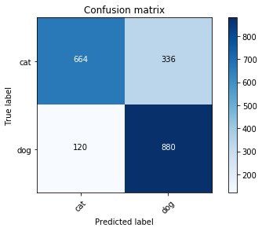

```
Testaccuracy: 0.772
```

```python
#load model
print('load model')
modelPath="Dogs-vs-Cats/trainResults/"
modelName='model_cnn_rgb_batchnorm_mean'
model = load_model(modelPath+modelName+'.h5')

#connect to image directory
print('load image')
imagePath="Dogs-vs-Cats/testDataSetMean/"
files=os.listdir(imagePath)

#load means
with open("Dogs-vs-Cats/means.pickle", "rb") as input_file:
    means = pickle.load(input_file)

#classification parameter
dim=model.input.shape.as_list()
classes={'cat':0,'dog':1}

actualClasses=[]
predictedClasses=[]
diff=[]

#iterate image files
for file in tqdm(files):
    #load image
    img = imageio.imread(imagePath+file,as_gray=False)
    label = classes[file.split('(')[0]]

    #scale image
    img = cv2.resize(img, dsize=(dim[1],dim[2]), interpolation=cv2.INTER_CUBIC)
    img = meanSubstraction(img,means)
    img = np.reshape(img,[1,dim[1],dim[2],3])
    prediction = model.predict(img)

    actualClasses.append(label)
    predictedClasses.append(np.argmax(prediction))

#confusion matrix
conf=confusion_matrix(actualClasses, predictedClasses)

plt.figure()
plot_confusion_matrix(conf, classes=list(classes.keys()), title='Confusion matrix')
plt.savefig(modelPath+'_confMat_'+modelName)
plt.show()

#calculate test accuracy
diff=[1 if x[0]!=x[1] else 0 for x in zip(actualClasses,predictedClasses)]
print('Testaccuracy: {0}'.format(1-sum(diff)/len(diff)))
```

**CNN with RGB Images, Mean Substraction, Batch-Normalization, Dropout and L2-Regularization:**

```
Train on 16100 samples, validate on 6900 samples
Trainingduration: 0:05:52.362361
```

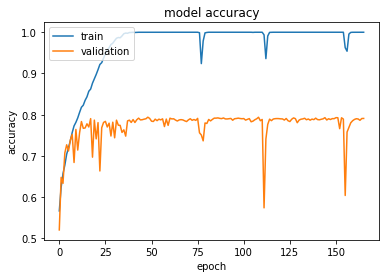

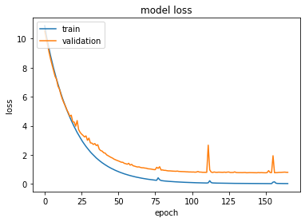

```python
#load data

dataDirectory="Dogs-vs-Cats/dataSetMean/"
output="Dogs-vs-Cats/trainResults/"
modelName='model_cnn_rgb_reg_mean'

#manage directory
if not os.path.exists(output):
    os.makedirs(output)

#parameter
batchSize=128
epochs=1000
validationSplit=0.30

features = dataDirectory+'data_m.npy'
X = np.load(features)

labels = dataDirectory+'labels_m.npy'
y = np.load(labels)

#%% Callbacks
callbacks=[]
callbacks.append(EarlyStopping(monitor='val_loss',patience=15,verbose=0, mode='auto'))
callbacks.append(ModelCheckpoint(output+modelName+'_check_.h5', save_best_only=True, monitor='val_loss', mode='min'))

seed = 7

#Split into train/test sets
X_train, X_val, y_train, y_val = train_test_split(X, y, test_size=validationSplit,random_state=seed,stratify=y)
steps_per_epoch=len(X_train)//batchSize

model=getCNN_reg(np.shape(X[0]),2)

#compile model

opt=optimizers.SGD(lr=0.001,momentum=0.9)
model.compile(optimizer=opt , loss='categorical_crossentropy', metrics=['accuracy'])

#Train Model
t = time.time()
hist = model.fit(X_train, y_train, batch_size=batchSize, epochs=epochs,validation_data=(X_val, y_val), callbacks=callbacks,verbose=1)

elapsed = time.time() - t
print('Trainingduration: '+str(datetime.timedelta(seconds=elapsed)))

#save model
model.save(output+modelName+'.h5')

#generate and save plots
# plot history for accuracy
plt.figure()
plt.ioff()
plt.plot(hist.history['accuracy'])
plt.plot(hist.history['val_accuracy'])
plt.title('model accuracy')
plt.ylabel('accuracy')
plt.xlabel('epoch')
plt.legend(['train', 'validation'], loc='upper left')
plt.savefig(output+'_accuracy_'+modelName)

# plot history for loss
plt.figure()
plt.ioff()
plt.plot(hist.history['loss'])
plt.plot(hist.history['val_loss'])
plt.title('model loss')
plt.ylabel('loss')
plt.xlabel('epoch')
plt.legend(['train', 'validation'], loc='upper left')
plt.savefig(output+'_loss_'+modelName)

#save detail information
with open(output+modelName+".txt","w+") as f:

    f.write('Trainparameter:\n')
    f.write('ValidationSplit: {0}\n'.format(validationSplit))
    f.write('Batchsize: {0}\n'.format(batchSize))
    f.write('Epochs: {0}\n'.format(epochs))
    f.write('Steps per epoch: {0}\n'.format(steps_per_epoch))
    f.write('Inputdimension:\n'+str(np.shape(X_train[0])))
    f.write('\n')
    f.write('Results:\n')
    f.write('Trainaccuracy: {0}\n'.format(hist.history['accuracy'][-1]*100))
    f.write('Validationaccuracy: {0}\n'.format(hist.history['val_accuracy'][-1]*100))
    f.write('Best Validation: {0}\n'.format(np.max(hist.history['val_accuracy'])*100))
    f.write('\n')
    f.write('Modelarchitecture:\n')
    with redirect_stdout(f):
        model.summary()
```

```
load model
```

```
load image
```

```
Confusion matrix, without normalization
[[799 201]
 [221 779]]
```

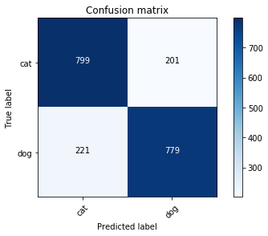

```
Testaccuracy: 0.789
```

```python
#load model
print('load model')
modelPath="Dogs-vs-Cats/trainResults/"
modelName='model_cnn_rgb_reg_mean'
model = load_model(modelPath+modelName+'.h5')

#connect to image directory
print('load image')
imagePath="Dogs-vs-Cats/testDataSetMean/"
files=os.listdir(imagePath)

#load means
with open("Dogs-vs-Cats/means.pickle", "rb") as input_file:
    means = pickle.load(input_file)

#classification parameter
dim=model.input.shape.as_list()
classes={'cat':0,'dog':1}

actualClasses=[]
predictedClasses=[]
diff=[]

#iterate image files
for file in tqdm(files):
    #load image
    img = imageio.imread(imagePath+file,as_gray=False)
    label = classes[file.split('(')[0]]

    #scale image
    img = cv2.resize(img, dsize=(dim[1],dim[2]), interpolation=cv2.INTER_CUBIC)
    img = meanSubstraction(img,means)
    img = np.reshape(img,[1,dim[1],dim[2],3])
    prediction = model.predict(img)

    actualClasses.append(label)
    predictedClasses.append(np.argmax(prediction))

#confusion matrix
conf=confusion_matrix(actualClasses, predictedClasses)

plt.figure()
plot_confusion_matrix(conf, classes=list(classes.keys()), title='Confusion matrix')
plt.savefig(modelPath+'_confMat_'+modelName)
plt.show()

#calculate test accuracy
diff=[1 if x[0]!=x[1] else 0 for x in zip(actualClasses,predictedClasses)]
print('Testaccuracy: {0}'.format(1-sum(diff)/len(diff)))
```

**Resnet with RGB Images and Mean Substraction:**

```
Train on 16100 samples, validate on 6900 samples
Trainingduration: 0:07:29.949853
```

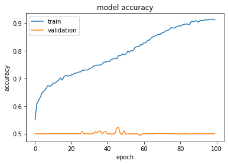

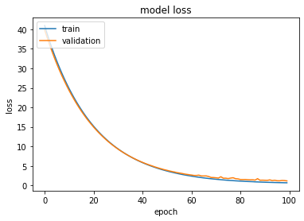

```python
#load data

dataDirectory="Dogs-vs-Cats/dataSetMean/"
output="Dogs-vs-Cats/trainResults/"
modelName='model_cnn_rgb_resnet_mean'

#manage directory
if not os.path.exists(output):
    os.makedirs(output)

#parameter
batchSize=128
epochs=100
validationSplit=0.30

features = dataDirectory+'data_m.npy'
X = np.load(features)

labels = dataDirectory+'labels_m.npy'
y = np.load(labels)

#%% Callbacks
callbacks=[]
callbacks.append(EarlyStopping(monitor='val_loss',patience=15,verbose=0, mode='auto'))
callbacks.append(ModelCheckpoint(output+modelName+'_check_.h5', save_best_only=True, monitor='val_loss', mode='min'))

seed = 7

#Split into train/test sets
X_train, X_val, y_train, y_val = train_test_split(X, y, test_size=validationSplit,random_state=seed,stratify=y)
steps_per_epoch=len(X_train)//batchSize

model=getResnet(np.shape(X[0]),2)

#compile model

opt=optimizers.SGD(lr=0.001,momentum=0.9)
model.compile(optimizer=opt , loss='categorical_crossentropy', metrics=['accuracy'])

#Train Model
t = time.time()
hist = model.fit(X_train, y_train, batch_size=batchSize, epochs=epochs,validation_data=(X_val, y_val), callbacks=callbacks,verbose=1)

elapsed = time.time() - t
print('Trainingduration: '+str(datetime.timedelta(seconds=elapsed)))

#save model
model.save(output+modelName+'.h5')

#generate and save plots
# plot history for accuracy
plt.figure()
plt.ioff()
plt.plot(hist.history['accuracy'])
plt.plot(hist.history['val_accuracy'])
plt.title('model accuracy')
plt.ylabel('accuracy')
plt.xlabel('epoch')
plt.legend(['train', 'validation'], loc='upper left')
plt.savefig(output+'_accuracy_'+modelName)

# plot history for loss
plt.figure()
plt.ioff()
plt.plot(hist.history['loss'])
plt.plot(hist.history['val_loss'])
plt.title('model loss')
plt.ylabel('loss')
plt.xlabel('epoch')
plt.legend(['train', 'validation'], loc='upper left')
plt.savefig(output+'_loss_'+modelName)

#save detail information
with open(output+modelName+".txt","w+") as f:

    f.write('Trainparameter:\n')
    f.write('ValidationSplit: {0}\n'.format(validationSplit))
    f.write('Batchsize: {0}\n'.format(batchSize))
    f.write('Epochs: {0}\n'.format(epochs))
    f.write('Steps per epoch: {0}\n'.format(steps_per_epoch))
    f.write('Inputdimension:\n'+str(np.shape(X_train[0])))
    f.write('\n')
    f.write('Results:\n')
    f.write('Trainaccuracy: {0}\n'.format(hist.history['accuracy'][-1]*100))
    f.write('Validationaccuracy: {0}\n'.format(hist.history['val_accuracy'][-1]*100))
    f.write('Best Validation: {0}\n'.format(np.max(hist.history['val_accuracy'])*100))
    f.write('\n')
    f.write('Modelarchitecture:\n')
    with redirect_stdout(f):
        model.summary()
```

```
load model
```

```
load image
```

```
Confusion matrix, without normalization
[[   0 1000]
 [   0 1000]]
```

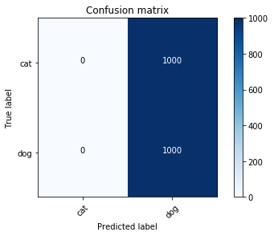

```
Testaccuracy: 0.5
```

```python
#load model
print('load model')
modelPath="Dogs-vs-Cats/trainResults/"
modelName='model_cnn_rgb_resnet_mean'
model = load_model(modelPath+modelName+'.h5')

#connect to image directory
print('load image')
imagePath="Dogs-vs-Cats/testDataSetMean/"
files=os.listdir(imagePath)

#load means
with open("Dogs-vs-Cats/means.pickle", "rb") as input_file:
    means = pickle.load(input_file)

#classification parameter
dim=model.input.shape.as_list()
classes={'cat':0,'dog':1}

actualClasses=[]
predictedClasses=[]
diff=[]

#iterate image files
for file in tqdm(files):
    #load image
    img = imageio.imread(imagePath+file,as_gray=False)
    label = classes[file.split('(')[0]]

    #scale image
    img = cv2.resize(img, dsize=(dim[1],dim[2]), interpolation=cv2.INTER_CUBIC)
    img = meanSubstraction(img,means)
    img = np.reshape(img,[1,dim[1],dim[2],3])
    prediction = model.predict(img)

    actualClasses.append(label)
    predictedClasses.append(np.argmax(prediction))

#confusion matrix
conf=confusion_matrix(actualClasses, predictedClasses)

plt.figure()
plot_confusion_matrix(conf, classes=list(classes.keys()), title='Confusion matrix')
plt.savefig(modelPath+'_confMat_'+modelName)
plt.show()

#calculate test accuracy
diff=[1 if x[0]!=x[1] else 0 for x in zip(actualClasses,predictedClasses)]
print('Testaccuracy: {0}'.format(1-sum(diff)/len(diff)))
```

**VGG16 with RGB Images and Mean Substraction:**

```
Train on 16100 samples, validate on 6900 samples
Trainingduration: 0:06:57.329994
```

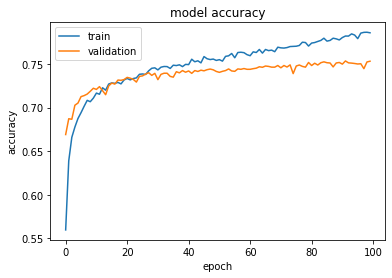

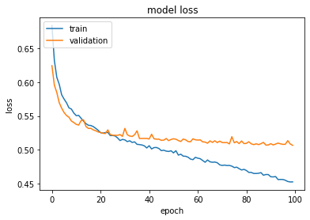

```python
#load data

dataDirectory="Dogs-vs-Cats/dataSetMean/"
output="Dogs-vs-Cats/trainResults/"
modelName='model_cnn_rgb_vgg_mean'

#manage directory
if not os.path.exists(output):
    os.makedirs(output)

#parameter
batchSize=128
epochs=100
validationSplit=0.30

features = dataDirectory+'data_m.npy'
X = np.load(features)

labels = dataDirectory+'labels_m.npy'
y = np.load(labels)

#%% Callbacks
callbacks=[]
callbacks.append(EarlyStopping(monitor='val_loss',patience=15,verbose=0, mode='auto'))
callbacks.append(ModelCheckpoint(output+modelName+'_check_.h5', save_best_only=True, monitor='val_loss', mode='min'))

seed = 7

#Split into train/test sets
X_train, X_val, y_train, y_val = train_test_split(X, y, test_size=validationSplit,random_state=seed,stratify=y)
steps_per_epoch=len(X_train)//batchSize

model=vgg16(np.shape(X[0]),2)

#compile model

opt=optimizers.SGD(lr=0.001,momentum=0.9)
model.compile(optimizer=opt , loss='categorical_crossentropy', metrics=['accuracy'])

#Train Model
t = time.time()
hist = model.fit(X_train, y_train, batch_size=batchSize, epochs=epochs,validation_data=(X_val, y_val), callbacks=callbacks,verbose=1)

elapsed = time.time() - t
print('Trainingduration: '+str(datetime.timedelta(seconds=elapsed)))

#save model
model.save(output+modelName+'.h5')

#generate and save plots
# plot history for accuracy
plt.figure()
plt.ioff()
plt.plot(hist.history['accuracy'])
plt.plot(hist.history['val_accuracy'])
plt.title('model accuracy')
plt.ylabel('accuracy')
plt.xlabel('epoch')
plt.legend(['train', 'validation'], loc='upper left')
plt.savefig(output+'_accuracy_'+modelName)

# plot history for loss
plt.figure()
plt.ioff()
plt.plot(hist.history['loss'])
plt.plot(hist.history['val_loss'])
plt.title('model loss')
plt.ylabel('loss')
plt.xlabel('epoch')
plt.legend(['train', 'validation'], loc='upper left')
plt.savefig(output+'_loss_'+modelName)

#save detail information
with open(output+modelName+".txt","w+") as f:

    f.write('Trainparameter:\n')
    f.write('ValidationSplit: {0}\n'.format(validationSplit))
    f.write('Batchsize: {0}\n'.format(batchSize))
    f.write('Epochs: {0}\n'.format(epochs))
    f.write('Steps per epoch: {0}\n'.format(steps_per_epoch))
    f.write('Inputdimension:\n'+str(np.shape(X_train[0])))
    f.write('\n')
    f.write('Results:\n')
    f.write('Trainaccuracy: {0}\n'.format(hist.history['accuracy'][-1]*100))
    f.write('Validationaccuracy: {0}\n'.format(hist.history['val_accuracy'][-1]*100))
    f.write('Best Validation: {0}\n'.format(np.max(hist.history['val_accuracy'])*100))
    f.write('\n')
    f.write('Modelarchitecture:\n')
    with redirect_stdout(f):
        model.summary()
```

```
load model
```

```
load image
```

```
Confusion matrix, without normalization
[[764 236]
 [278 722]]
```

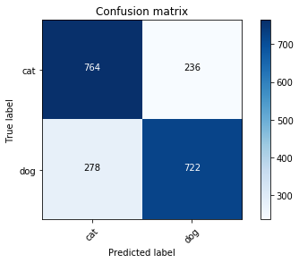

```
Testaccuracy: 0.743
```

```python
#load model
print('load model')
modelPath="Dogs-vs-Cats/trainResults/"
modelName='model_cnn_rgb_vgg_mean'
model = load_model(modelPath+modelName+'.h5')

#connect to image directory
print('load image')
imagePath="Dogs-vs-Cats/testDataSetMean/"
files=os.listdir(imagePath)

#load means
with open("Dogs-vs-Cats/means.pickle", "rb") as input_file:
    means = pickle.load(input_file)

#classification parameter
dim=model.input.shape.as_list()
classes={'cat':0,'dog':1}

actualClasses=[]
predictedClasses=[]
diff=[]

#iterate image files
for file in tqdm(files):
    #load image
    img = imageio.imread(imagePath+file,as_gray=False)
    label = classes[file.split('(')[0]]

    #scale image
    img = cv2.resize(img, dsize=(dim[1],dim[2]), interpolation=cv2.INTER_CUBIC)
    img = meanSubstraction(img,means)
    img = np.reshape(img,[1,dim[1],dim[2],3])
    prediction = model.predict(img)

    actualClasses.append(label)
    predictedClasses.append(np.argmax(prediction))

#confusion matrix
conf=confusion_matrix(actualClasses, predictedClasses)

plt.figure()
plot_confusion_matrix(conf, classes=list(classes.keys()), title='Confusion matrix')
plt.savefig(modelPath+'_confMat_'+modelName)
plt.show()

#calculate test accuracy
diff=[1 if x[0]!=x[1] else 0 for x in zip(actualClasses,predictedClasses)]
print('Testaccuracy: {0}'.format(1-sum(diff)/len(diff)))
```

**VGG16 with RGB Images, Mean Substraction and Fine Tuning:**

```
Train on 16100 samples, validate on 6900 samples
Trainingduration: 0:10:27.040762
```

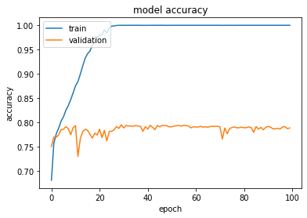

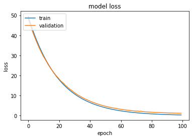

```python
#load data

dataDirectory="Dogs-vs-Cats/dataSetMean/"
output="Dogs-vs-Cats/trainResults/"
modelName='model_cnn_rgb_vgg2_mean'

#manage directory
if not os.path.exists(output):
    os.makedirs(output)

#parameter
batchSize=128
epochs=100
validationSplit=0.30

features = dataDirectory+'data_m.npy'
X = np.load(features)

labels = dataDirectory+'labels_m.npy'
y = np.load(labels)

#%% Callbacks
callbacks=[]
callbacks.append(EarlyStopping(monitor='val_loss',patience=15,verbose=0, mode='auto'))
callbacks.append(ModelCheckpoint(output+modelName+'_check_.h5', save_best_only=True, monitor='val_loss', mode='min'))

seed = 7

#Split into train/test sets
X_train, X_val, y_train, y_val = train_test_split(X, y, test_size=validationSplit,random_state=seed,stratify=y)
steps_per_epoch=len(X_train)//batchSize

model=vgg16v2(np.shape(X[0]),2)

#compile model

opt=optimizers.SGD(lr=0.001,momentum=0.9)
model.compile(optimizer=opt , loss='categorical_crossentropy', metrics=['accuracy'])

#Train Model
t = time.time()
hist = model.fit(X_train, y_train, batch_size=batchSize, epochs=epochs,validation_data=(X_val, y_val), callbacks=callbacks,verbose=1)

elapsed = time.time() - t
print('Trainingduration: '+str(datetime.timedelta(seconds=elapsed)))

#save model
model.save(output+modelName+'.h5')

#generate and save plots
# plot history for accuracy
plt.figure()
plt.ioff()
plt.plot(hist.history['accuracy'])
plt.plot(hist.history['val_accuracy'])
plt.title('model accuracy')
plt.ylabel('accuracy')
plt.xlabel('epoch')
plt.legend(['train', 'validation'], loc='upper left')
plt.savefig(output+'_accuracy_'+modelName)

# plot history for loss
plt.figure()
plt.ioff()
plt.plot(hist.history['loss'])
plt.plot(hist.history['val_loss'])
plt.title('model loss')
plt.ylabel('loss')
plt.xlabel('epoch')
plt.legend(['train', 'validation'], loc='upper left')
plt.savefig(output+'_loss_'+modelName)

#save detail information
with open(output+modelName+".txt","w+") as f:

    f.write('Trainparameter:\n')
    f.write('ValidationSplit: {0}\n'.format(validationSplit))
    f.write('Batchsize: {0}\n'.format(batchSize))
    f.write('Epochs: {0}\n'.format(epochs))
    f.write('Steps per epoch: {0}\n'.format(steps_per_epoch))
    f.write('Inputdimension:\n'+str(np.shape(X_train[0])))
    f.write('\n')
    f.write('Results:\n')
    f.write('Trainaccuracy: {0}\n'.format(hist.history['accuracy'][-1]*100))
    f.write('Validationaccuracy: {0}\n'.format(hist.history['val_accuracy'][-1]*100))
    f.write('Best Validation: {0}\n'.format(np.max(hist.history['val_accuracy'])*100))
    f.write('\n')
    f.write('Modelarchitecture:\n')
    with redirect_stdout(f):
        model.summary()
```

```
load model
```

```
load image
```

```
Confusion matrix, without normalization
[[776 224]
 [190 810]]
```

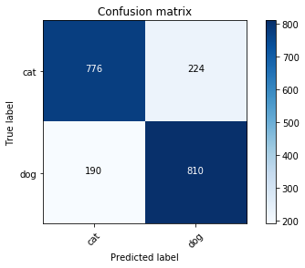

```
Testaccuracy: 0.793
```

```python
#load model
print('load model')
modelPath="Dogs-vs-Cats/trainResults/"
modelName='model_cnn_rgb_vgg2_mean'
model = load_model(modelPath+modelName+'.h5')

#connect to image directory
print('load image')
imagePath="Dogs-vs-Cats/testDataSetMean/"
files=os.listdir(imagePath)

#load means
with open("Dogs-vs-Cats/means.pickle", "rb") as input_file:
    means = pickle.load(input_file)

#classification parameter
dim=model.input.shape.as_list()
classes={'cat':0,'dog':1}

actualClasses=[]
predictedClasses=[]
diff=[]

#iterate image files
for file in tqdm(files):
    #load image
    img = imageio.imread(imagePath+file,as_gray=False)
    label = classes[file.split('(')[0]]

    #scale image
    img = cv2.resize(img, dsize=(dim[1],dim[2]), interpolation=cv2.INTER_CUBIC)
    img = meanSubstraction(img,means)
    img = np.reshape(img,[1,dim[1],dim[2],3])
    prediction = model.predict(img)

    actualClasses.append(label)
    predictedClasses.append(np.argmax(prediction))

#confusion matrix
conf=confusion_matrix(actualClasses, predictedClasses)

plt.figure()
plot_confusion_matrix(conf, classes=list(classes.keys()), title='Confusion matrix')
plt.savefig(modelPath+'_confMat_'+modelName)
plt.show()

#calculate test accuracy
diff=[1 if x[0]!=x[1] else 0 for x in zip(actualClasses,predictedClasses)]
print('Testaccuracy: {0}'.format(1-sum(diff)/len(diff)))
```

**CNN with Greyscale Images:**

```python
imagePath="Dogs-vs-Cats/images/"
dataPath="Dogs-vs-Cats/"
output=dataPath+'/dataSetGrey/'
testDir=dataPath+'./testDataSetGrey/'

#manage directory
if not os.path.exists(output):
    os.makedirs(output)

if not os.path.exists(testDir):
    os.makedirs(testDir)

classNames=os.listdir(imagePath)
classes={classNames[i]: i for i in range(len(classNames))}

#dataset parameter
data=[]
labels=[]
testSize=1000
size=np.minimum(minx,miny)

#create datasets
for className in tqdm(classNames):
  print('\n'+className+'\n')
  classFiles=os.listdir(imagePath+className)
  classFiles=[x for x in classFiles if x.endswith('.jpg')]
  for i in range(testSize):
    file=classFiles[i]
    try:
        src=imagePath+className+"/"+file
        dst=testDir+"/"+className+'('+str(i)+').jpg'
        shutil.copy(src,dst)
    except:
        print('Could not copy file:\n'+file)
  classFiles=classFiles[testSize:]
  for file in classFiles:
    try:
        img = imageio.imread(imagePath+className+"/"+file,as_gray=True)
        label = classes[className]

        #scale image
        img = cv2.resize(img, dsize=(size,size), interpolation=cv2.INTER_CUBIC)
        img=np.reshape(img,(size,size,1))
        data.append(img.astype('float32'))
        labels.append(label)
    except Exception as e:
        print(e)
        print('Failed to process file:\n'+imagePath+className+"/"+file)

#class balancing
limit=min(Counter(labels).values())

#create final dataset
labelsBalanced=[]
dataBalanced=[]
classes=np.unique(labels)
for c in classes:
    print('Class {0}'.format(c))
    idx = np.where(labels == c)
    idx = idx[0].tolist()
    np.random.shuffle(idx)
    for i in tqdm(range(0,limit)):
        labelsBalanced.append(c)
        dataBalanced.append(data[idx[i]])

del labels
del data

#one hot encoding for classlabels
from sklearn.preprocessing import LabelEncoder
from keras.utils import np_utils

lab = LabelEncoder()
encodedLabels = np_utils.to_categorical(lab.fit_transform(labelsBalanced))

#save dataset + labels
np.save(output+'data_g', dataBalanced)
np.save(output+'labels_g', encodedLabels)
```

```
cat
```

```
dog
```

```
Class 0
Class 1
```

```
Train on 16100 samples, validate on 6900 samples
Trainingduration: 0:00:52.541560
```

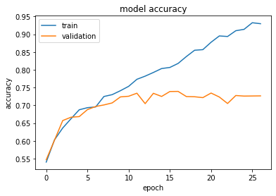

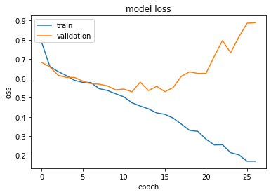

```python
#load data

dataDirectory="Dogs-vs-Cats/dataSetGrey/"
output="Dogs-vs-Cats/trainResults/"
modelName='model_cnn_grey'

#manage directory
if not os.path.exists(output):
    os.makedirs(output)

#parameter
batchSize=128
epochs=1000
validationSplit=0.30

features = dataDirectory+'data_g.npy'
X = np.load(features)

labels = dataDirectory+'labels_g.npy'
y = np.load(labels)

#%% Callbacks
callbacks=[]
callbacks.append(EarlyStopping(monitor='val_loss',patience=15,verbose=0, mode='auto'))
callbacks.append(ModelCheckpoint(output+modelName+'_check_.h5', save_best_only=True, monitor='val_loss', mode='min'))

seed = 7

#Split into train/test sets
X_train, X_val, y_train, y_val = train_test_split(X, y, test_size=validationSplit,random_state=seed,stratify=y)
steps_per_epoch=len(X_train)//batchSize

model=getCNN(np.shape(X[0]),2)

#compile model

opt=optimizers.SGD(lr=0.001,momentum=0.9)
model.compile(optimizer=opt , loss='categorical_crossentropy', metrics=['accuracy'])

#Train Model
t = time.time()
hist = model.fit(X_train, y_train, batch_size=batchSize, epochs=epochs,validation_data=(X_val, y_val), callbacks=callbacks,verbose=1)

elapsed = time.time() - t
print('Trainingduration: '+str(datetime.timedelta(seconds=elapsed)))

#save model
model.save(output+modelName+'.h5')

#generate and save plots
# plot history for accuracy
plt.figure()
plt.ioff()
plt.plot(hist.history['accuracy'])
plt.plot(hist.history['val_accuracy'])
plt.title('model accuracy')
plt.ylabel('accuracy')
plt.xlabel('epoch')
plt.legend(['train', 'validation'], loc='upper left')
plt.savefig(output+'_accuracy_'+modelName)

# plot history for loss
plt.figure()
plt.ioff()
plt.plot(hist.history['loss'])
plt.plot(hist.history['val_loss'])
plt.title('model loss')
plt.ylabel('loss')
plt.xlabel('epoch')
plt.legend(['train', 'validation'], loc='upper left')
plt.savefig(output+'_loss_'+modelName)

#save detail information
with open(output+modelName+".txt","w+") as f:

    f.write('Trainparameter:\n')
    f.write('ValidationSplit: {0}\n'.format(validationSplit))
    f.write('Batchsize: {0}\n'.format(batchSize))
    f.write('Epochs: {0}\n'.format(epochs))
    f.write('Steps per epoch: {0}\n'.format(steps_per_epoch))
    f.write('Inputdimension:\n'+str(np.shape(X_train[0])))
    f.write('\n')
    f.write('Results:\n')
    f.write('Trainaccuracy: {0}\n'.format(hist.history['accuracy'][-1]*100))
    f.write('Validationaccuracy: {0}\n'.format(hist.history['val_accuracy'][-1]*100))
    f.write('Best Validation: {0}\n'.format(np.max(hist.history['val_accuracy'])*100))
    f.write('\n')
    f.write('Modelarchitecture:\n')
    with redirect_stdout(f):
        model.summary()
```

```
load model
```

```
load image
```

```
Confusion matrix, without normalization
[[673 327]
 [224 776]]
```

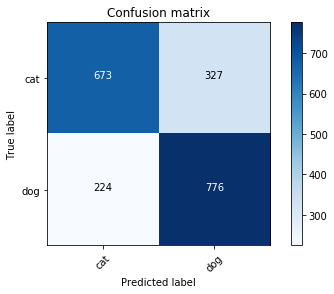

```
Testaccuracy: 0.7244999999999999
```

```python
#load model
print('load model')
modelPath="Dogs-vs-Cats/trainResults/"
modelName='model_cnn_grey'
model = load_model(modelPath+modelName+'.h5')

#connect to image directory
print('load image')
imagePath="Dogs-vs-Cats/testDataSetGrey/"
files=os.listdir(imagePath)

#load means
with open("Dogs-vs-Cats/means.pickle", "rb") as input_file:
    means = pickle.load(input_file)

#classification parameter
dim=model.input.shape.as_list()
classes={'cat':0,'dog':1}

actualClasses=[]
predictedClasses=[]
diff=[]

#iterate image files
for file in tqdm(files):
    #load image
    img = imageio.imread(imagePath+file,as_gray=True)
    label = classes[file.split('(')[0]]

    #scale image
    img = cv2.resize(img, dsize=(dim[1],dim[2]), interpolation=cv2.INTER_CUBIC)
    img = np.reshape(img,[1,dim[1],dim[2],1])
    prediction = model.predict(img)

    actualClasses.append(label)
    predictedClasses.append(np.argmax(prediction))

#confusion matrix
conf=confusion_matrix(actualClasses, predictedClasses)

plt.figure()
plot_confusion_matrix(conf, classes=list(classes.keys()), title='Confusion matrix')
plt.savefig(modelPath+'_confMat_'+modelName)
plt.show()

#calculate test accuracy
diff=[1 if x[0]!=x[1] else 0 for x in zip(actualClasses,predictedClasses)]
print('Testaccuracy: {0}'.format(1-sum(diff)/len(diff)))
```

**CNN with Greyscale Images and Batch-Normalization/Dropout:**

```
Train on 16100 samples, validate on 6900 samples
Trainingduration: 0:01:09.110813
```

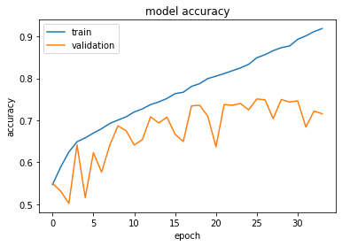

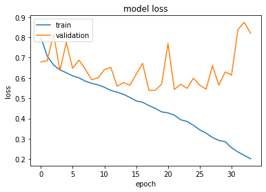

```python
#load data

dataDirectory="Dogs-vs-Cats/dataSetGrey/"
output="Dogs-vs-Cats/trainResults/"
modelName='model_cnn_grey_batchnorm'

#manage directory
if not os.path.exists(output):
    os.makedirs(output)

#parameter
batchSize=128
epochs=1000
validationSplit=0.30

features = dataDirectory+'data_g.npy'
X = np.load(features)

labels = dataDirectory+'labels_g.npy'
y = np.load(labels)

#%% Callbacks
callbacks=[]
callbacks.append(EarlyStopping(monitor='val_loss',patience=15,verbose=0, mode='auto'))
callbacks.append(ModelCheckpoint(output+modelName+'_check_.h5', save_best_only=True, monitor='val_loss', mode='min'))

seed = 7

#Split into train/test sets
X_train, X_val, y_train, y_val = train_test_split(X, y, test_size=validationSplit,random_state=seed,stratify=y)
steps_per_epoch=len(X_train)//batchSize

model=getCNN_batchnorm(np.shape(X[0]),2)

#compile model

opt=optimizers.SGD(lr=0.001,momentum=0.9)
model.compile(optimizer=opt , loss='categorical_crossentropy', metrics=['accuracy'])

#Train Model
t = time.time()
hist = model.fit(X_train, y_train, batch_size=batchSize, epochs=epochs,validation_data=(X_val, y_val), callbacks=callbacks,verbose=1)

elapsed = time.time() - t
print('Trainingduration: '+str(datetime.timedelta(seconds=elapsed)))

#save model
model.save(output+modelName+'.h5')

#generate and save plots
# plot history for accuracy
plt.figure()
plt.ioff()
plt.plot(hist.history['accuracy'])
plt.plot(hist.history['val_accuracy'])
plt.title('model accuracy')
plt.ylabel('accuracy')
plt.xlabel('epoch')
plt.legend(['train', 'validation'], loc='upper left')
plt.savefig(output+'_accuracy_'+modelName)

# plot history for loss
plt.figure()
plt.ioff()
plt.plot(hist.history['loss'])
plt.plot(hist.history['val_loss'])
plt.title('model loss')
plt.ylabel('loss')
plt.xlabel('epoch')
plt.legend(['train', 'validation'], loc='upper left')
plt.savefig(output+'_loss_'+modelName)

#save detail information
with open(output+modelName+".txt","w+") as f:

    f.write('Trainparameter:\n')
    f.write('ValidationSplit: {0}\n'.format(validationSplit))
    f.write('Batchsize: {0}\n'.format(batchSize))
    f.write('Epochs: {0}\n'.format(epochs))
    f.write('Steps per epoch: {0}\n'.format(steps_per_epoch))
    f.write('Inputdimension:\n'+str(np.shape(X_train[0])))
    f.write('\n')
    f.write('Results:\n')
    f.write('Trainaccuracy: {0}\n'.format(hist.history['accuracy'][-1]*100))
    f.write('Validationaccuracy: {0}\n'.format(hist.history['val_accuracy'][-1]*100))
    f.write('Best Validation: {0}\n'.format(np.max(hist.history['val_accuracy'])*100))
    f.write('\n')
    f.write('Modelarchitecture:\n')
    with redirect_stdout(f):
        model.summary()
```

```
load model
```

```
load image
```

```
Confusion matrix, without normalization
[[899 101]
 [476 524]]
```

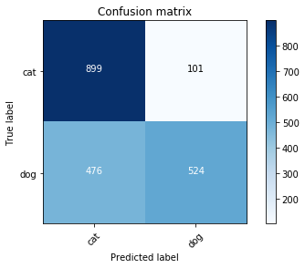

```
Testaccuracy: 0.7115
```

```python
#load model
print('load model')
modelPath="Dogs-vs-Cats/trainResults/"
modelName='model_cnn_grey_batchnorm'
model = load_model(modelPath+modelName+'.h5')

#connect to image directory
print('load image')
imagePath="Dogs-vs-Cats/testDataSetGrey/"
files=os.listdir(imagePath)

#load means
with open("Dogs-vs-Cats/means.pickle", "rb") as input_file:
    means = pickle.load(input_file)

#classification parameter
dim=model.input.shape.as_list()
classes={'cat':0,'dog':1}

actualClasses=[]
predictedClasses=[]
diff=[]

#iterate image files
for file in tqdm(files):
    #load image
    img = imageio.imread(imagePath+file,as_gray=True)
    label = classes[file.split('(')[0]]

    #scale image
    img = cv2.resize(img, dsize=(dim[1],dim[2]), interpolation=cv2.INTER_CUBIC)
    img = np.reshape(img,[1,dim[1],dim[2],1])
    prediction = model.predict(img)

    actualClasses.append(label)
    predictedClasses.append(np.argmax(prediction))

#confusion matrix
conf=confusion_matrix(actualClasses, predictedClasses)

plt.figure()
plot_confusion_matrix(conf, classes=list(classes.keys()), title='Confusion matrix')
plt.savefig(modelPath+'_confMat_'+modelName)
plt.show()

#calculate test accuracy
diff=[1 if x[0]!=x[1] else 0 for x in zip(actualClasses,predictedClasses)]
print('Testaccuracy: {0}'.format(1-sum(diff)/len(diff)))
```

**CNN with Greyscale Images, Batchnorm, Dropout and L2-Regularization:**

```
Train on 16100 samples, validate on 6900 samples
Trainingduration: 0:05:27.425499
```

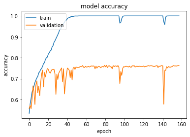

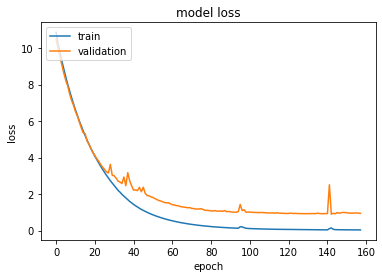

```python
#load data

dataDirectory="Dogs-vs-Cats/dataSetGrey/"
output="Dogs-vs-Cats/trainResults/"
modelName='model_cnn_grey_reg'

#manage directory
if not os.path.exists(output):
    os.makedirs(output)

#parameter
batchSize=128
epochs=1000
validationSplit=0.30

features = dataDirectory+'data_g.npy'
X = np.load(features)

labels = dataDirectory+'labels_g.npy'
y = np.load(labels)

#%% Callbacks
callbacks=[]
callbacks.append(EarlyStopping(monitor='val_loss',patience=15,verbose=0, mode='auto'))
callbacks.append(ModelCheckpoint(output+modelName+'_check_.h5', save_best_only=True, monitor='val_loss', mode='min'))

seed = 7

#Split into train/test sets
X_train, X_val, y_train, y_val = train_test_split(X, y, test_size=validationSplit,random_state=seed,stratify=y)
steps_per_epoch=len(X_train)//batchSize

model=getCNN_reg(np.shape(X[0]),2)

#compile model

opt=optimizers.SGD(lr=0.001,momentum=0.9)
model.compile(optimizer=opt , loss='categorical_crossentropy', metrics=['accuracy'])

#Train Model
t = time.time()
hist = model.fit(X_train, y_train, batch_size=batchSize, epochs=epochs,validation_data=(X_val, y_val), callbacks=callbacks,verbose=1)

elapsed = time.time() - t
print('Trainingduration: '+str(datetime.timedelta(seconds=elapsed)))

#save model
model.save(output+modelName+'.h5')

#generate and save plots
# plot history for accuracy
plt.figure()
plt.ioff()
plt.plot(hist.history['accuracy'])
plt.plot(hist.history['val_accuracy'])
plt.title('model accuracy')
plt.ylabel('accuracy')
plt.xlabel('epoch')
plt.legend(['train', 'validation'], loc='upper left')
plt.savefig(output+'_accuracy_'+modelName)

# plot history for loss
plt.figure()
plt.ioff()
plt.plot(hist.history['loss'])
plt.plot(hist.history['val_loss'])
plt.title('model loss')
plt.ylabel('loss')
plt.xlabel('epoch')
plt.legend(['train', 'validation'], loc='upper left')
plt.savefig(output+'_loss_'+modelName)

#save detail information
with open(output+modelName+".txt","w+") as f:

    f.write('Trainparameter:\n')
    f.write('ValidationSplit: {0}\n'.format(validationSplit))
    f.write('Batchsize: {0}\n'.format(batchSize))
    f.write('Epochs: {0}\n'.format(epochs))
    f.write('Steps per epoch: {0}\n'.format(steps_per_epoch))
    f.write('Inputdimension:\n'+str(np.shape(X_train[0])))
    f.write('\n')
    f.write('Results:\n')
    f.write('Trainaccuracy: {0}\n'.format(hist.history['accuracy'][-1]*100))
    f.write('Validationaccuracy: {0}\n'.format(hist.history['val_accuracy'][-1]*100))
    f.write('Best Validation: {0}\n'.format(np.max(hist.history['val_accuracy'])*100))
    f.write('\n')
    f.write('Modelarchitecture:\n')
    with redirect_stdout(f):
        model.summary()
```

```
load model
```

```
load image
```

```
Confusion matrix, without normalization
[[752 248]
 [226 774]]
```

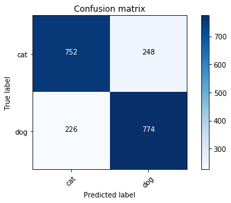

```
Testaccuracy: 0.763
```

```python
#load model
print('load model')
modelPath="Dogs-vs-Cats/trainResults/"
modelName='model_cnn_grey_reg'
model = load_model(modelPath+modelName+'.h5')

#connect to image directory
print('load image')
imagePath="Dogs-vs-Cats/testDataSetGrey/"
files=os.listdir(imagePath)

#load means
with open("Dogs-vs-Cats/means.pickle", "rb") as input_file:
    means = pickle.load(input_file)

#classification parameter
dim=model.input.shape.as_list()
classes={'cat':0,'dog':1}

actualClasses=[]
predictedClasses=[]
diff=[]

#iterate image files
for file in tqdm(files):
    #load image
    img = imageio.imread(imagePath+file,as_gray=True)
    label = classes[file.split('(')[0]]

    #scale image
    img = cv2.resize(img, dsize=(dim[1],dim[2]), interpolation=cv2.INTER_CUBIC)
    img = np.reshape(img,[1,dim[1],dim[2],1])
    prediction = model.predict(img)

    actualClasses.append(label)
    predictedClasses.append(np.argmax(prediction))

#confusion matrix
conf=confusion_matrix(actualClasses, predictedClasses)

plt.figure()
plot_confusion_matrix(conf, classes=list(classes.keys()), title='Confusion matrix')
plt.savefig(modelPath+'_confMat_'+modelName)
plt.show()

#calculate test accuracy
diff=[1 if x[0]!=x[1] else 0 for x in zip(actualClasses,predictedClasses)]
print('Testaccuracy: {0}'.format(1-sum(diff)/len(diff)))
```

**CNN with RGB Scaled Images:**

Would have liked to test even greater sizes, but ran out of RAM and diskspace unfortunately...

```python
imagePath="Dogs-vs-Cats/images/"
dataPath="Dogs-vs-Cats/"
output=dataPath+'/dataSetScaled/'
testDir=dataPath+'./testDataSetScaled/'

#manage directory
if not os.path.exists(output):
    os.makedirs(output)

if not os.path.exists(testDir):
    os.makedirs(testDir)

classNames=os.listdir(imagePath)
classes={classNames[i]: i for i in range(len(classNames))}

#dataset parameter
data=[]
labels=[]
testSize=1000
size=64

#create datasets
for className in tqdm(classNames):
  print('\n'+className+'\n')
  classFiles=os.listdir(imagePath+className)
  classFiles=[x for x in classFiles if x.endswith('.jpg')]
  for i in range(testSize):
    file=classFiles[i]
    try:
        src=imagePath+className+"/"+file
        dst=testDir+"/"+className+'('+str(i)+').jpg'
        shutil.copy(src,dst)
    except:
        print('Could not copy file:\n'+file)
  classFiles=classFiles[testSize:]
  for file in classFiles:
    try:
        img = imageio.imread(imagePath+className+"/"+file,as_gray=False)
        label = classes[className]

        #scale image
        img = cv2.resize(img, dsize=(size,size), interpolation=cv2.INTER_CUBIC)
        img=np.reshape(img,(size,size,3))
        data.append(img.astype('float32'))
        labels.append(label)
    except Exception as e:
        print(e)
        print('Failed to process file:\n'+imagePath+className+"/"+file)

#class balancing
limit=min(Counter(labels).values())

#create final dataset
labelsBalanced=[]
dataBalanced=[]
classes=np.unique(labels)
for c in classes:
    print('Class {0}'.format(c))
    idx = np.where(labels == c)
    idx = idx[0].tolist()
    np.random.shuffle(idx)
    for i in tqdm(range(0,limit)):
        labelsBalanced.append(c)
        dataBalanced.append(data[idx[i]])

del labels
del data

#one hot encoding for classlabels
from sklearn.preprocessing import LabelEncoder
from keras.utils import np_utils

lab = LabelEncoder()
encodedLabels = np_utils.to_categorical(lab.fit_transform(labelsBalanced))

#save dataset + labels
np.save(output+'data_s', dataBalanced)
np.save(output+'labels_s', encodedLabels)
```

```
cat
```

```
dog
```

```
Class 0
Class 1
```

```
Train on 16100 samples, validate on 6900 samples
Trainingduration: 0:02:14.514896
```

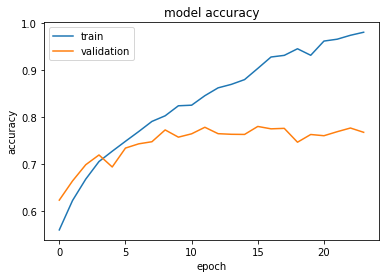

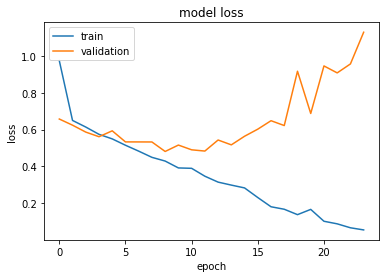

```python
#load data

dataDirectory="Dogs-vs-Cats/dataSetScaled/"
output="Dogs-vs-Cats/trainResults/"
modelName='model_cnn_rgbs'

#manage directory
if not os.path.exists(output):
    os.makedirs(output)

#parameter
batchSize=128
epochs=1000
validationSplit=0.30

features = dataDirectory+'data_s.npy'
X = np.load(features)

labels = dataDirectory+'labels_s.npy'
y = np.load(labels)

#%% Callbacks
callbacks=[]
callbacks.append(EarlyStopping(monitor='val_loss',patience=15,verbose=0, mode='auto'))
callbacks.append(ModelCheckpoint(output+modelName+'_check_.h5', save_best_only=True, monitor='val_loss', mode='min'))

seed = 7

#Split into train/test sets
X_train, X_val, y_train, y_val = train_test_split(X, y, test_size=validationSplit,random_state=seed,stratify=y)
steps_per_epoch=len(X_train)//batchSize

model=getCNN(np.shape(X[0]),2)

#compile model

opt=optimizers.SGD(lr=0.001,momentum=0.9)
model.compile(optimizer=opt , loss='categorical_crossentropy', metrics=['accuracy'])

#Train Model
t = time.time()
hist = model.fit(X_train, y_train, batch_size=batchSize, epochs=epochs,validation_data=(X_val, y_val), callbacks=callbacks,verbose=1)

elapsed = time.time() - t
print('Trainingduration: '+str(datetime.timedelta(seconds=elapsed)))

#save model
model.save(output+modelName+'.h5')

#generate and save plots
# plot history for accuracy
plt.figure()
plt.ioff()
plt.plot(hist.history['accuracy'])
plt.plot(hist.history['val_accuracy'])
plt.title('model accuracy')
plt.ylabel('accuracy')
plt.xlabel('epoch')
plt.legend(['train', 'validation'], loc='upper left')
plt.savefig(output+'_accuracy_'+modelName)

# plot history for loss
plt.figure()
plt.ioff()
plt.plot(hist.history['loss'])
plt.plot(hist.history['val_loss'])
plt.title('model loss')
plt.ylabel('loss')
plt.xlabel('epoch')
plt.legend(['train', 'validation'], loc='upper left')
plt.savefig(output+'_loss_'+modelName)

#save detail information
with open(output+modelName+".txt","w+") as f:

    f.write('Trainparameter:\n')
    f.write('ValidationSplit: {0}\n'.format(validationSplit))
    f.write('Batchsize: {0}\n'.format(batchSize))
    f.write('Epochs: {0}\n'.format(epochs))
    f.write('Steps per epoch: {0}\n'.format(steps_per_epoch))
    f.write('Inputdimension:\n'+str(np.shape(X_train[0])))
    f.write('\n')
    f.write('Results:\n')
    f.write('Trainaccuracy: {0}\n'.format(hist.history['accuracy'][-1]*100))
    f.write('Validationaccuracy: {0}\n'.format(hist.history['val_accuracy'][-1]*100))
    f.write('Best Validation: {0}\n'.format(np.max(hist.history['val_accuracy'])*100))
    f.write('\n')
    f.write('Modelarchitecture:\n')
    with redirect_stdout(f):
        model.summary()
```

```
load model
```

```
load image
```

```
Confusion matrix, without normalization
[[710 290]
 [184 816]]
```

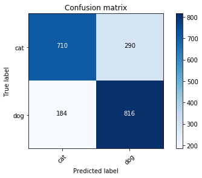

```
Testaccuracy: 0.763
```

```python
#load model
print('load model')
modelPath="Dogs-vs-Cats/trainResults/"
modelName='model_cnn_rgbs'
model = load_model(modelPath+modelName+'.h5')

#connect to image directory
print('load image')
imagePath="Dogs-vs-Cats/testDataSetScaled/"
files=os.listdir(imagePath)

#load means
with open("Dogs-vs-Cats/means.pickle", "rb") as input_file:
    means = pickle.load(input_file)

#classification parameter
dim=model.input.shape.as_list()
classes={'cat':0,'dog':1}

actualClasses=[]
predictedClasses=[]
diff=[]

#iterate image files
for file in tqdm(files):
    #load image
    img = imageio.imread(imagePath+file,as_gray=False)
    label = classes[file.split('(')[0]]

    #scale image
    img = cv2.resize(img, dsize=(dim[1],dim[2]), interpolation=cv2.INTER_CUBIC)
    img = np.reshape(img,[1,dim[1],dim[2],3])
    prediction = model.predict(img)

    actualClasses.append(label)
    predictedClasses.append(np.argmax(prediction))

#confusion matrix
conf=confusion_matrix(actualClasses, predictedClasses)

plt.figure()
plot_confusion_matrix(conf, classes=list(classes.keys()), title='Confusion matrix')
plt.savefig(modelPath+'_confMat_'+modelName)
plt.show()

#calculate test accuracy
diff=[1 if x[0]!=x[1] else 0 for x in zip(actualClasses,predictedClasses)]
print('Testaccuracy: {0}'.format(1-sum(diff)/len(diff)))
```

**CNN with RGB Scaled Images and Batch-Normalization/Dropout:**

```
Train on 16100 samples, validate on 6900 samples
Trainingduration: 0:03:45.625189
```

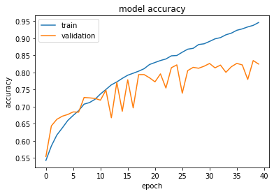

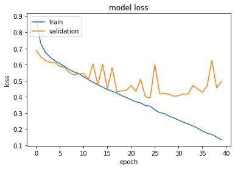

```python
#load data

dataDirectory="Dogs-vs-Cats/dataSetScaled/"
output="Dogs-vs-Cats/trainResults/"
modelName='model_cnn_rgbs_batchnorm'

#manage directory
if not os.path.exists(output):
    os.makedirs(output)

#parameter
batchSize=128
epochs=1000
validationSplit=0.30

features = dataDirectory+'data_s.npy'
X = np.load(features)

labels = dataDirectory+'labels_s.npy'
y = np.load(labels)

#%% Callbacks
callbacks=[]
callbacks.append(EarlyStopping(monitor='val_loss',patience=15,verbose=0, mode='auto'))
callbacks.append(ModelCheckpoint(output+modelName+'_check_.h5', save_best_only=True, monitor='val_loss', mode='min'))

seed = 7

#Split into train/test sets
X_train, X_val, y_train, y_val = train_test_split(X, y, test_size=validationSplit,random_state=seed,stratify=y)
steps_per_epoch=len(X_train)//batchSize

model=getCNN_batchnorm(np.shape(X[0]),2)

#compile model

opt=optimizers.SGD(lr=0.001,momentum=0.9)
model.compile(optimizer=opt , loss='categorical_crossentropy', metrics=['accuracy'])

#Train Model
t = time.time()
hist = model.fit(X_train, y_train, batch_size=batchSize, epochs=epochs,validation_data=(X_val, y_val), callbacks=callbacks,verbose=1)

elapsed = time.time() - t
print('Trainingduration: '+str(datetime.timedelta(seconds=elapsed)))

#save model
model.save(output+modelName+'.h5')

#generate and save plots
# plot history for accuracy
plt.figure()
plt.ioff()
plt.plot(hist.history['accuracy'])
plt.plot(hist.history['val_accuracy'])
plt.title('model accuracy')
plt.ylabel('accuracy')
plt.xlabel('epoch')
plt.legend(['train', 'validation'], loc='upper left')
plt.savefig(output+'_accuracy_'+modelName)

# plot history for loss
plt.figure()
plt.ioff()
plt.plot(hist.history['loss'])
plt.plot(hist.history['val_loss'])
plt.title('model loss')
plt.ylabel('loss')
plt.xlabel('epoch')
plt.legend(['train', 'validation'], loc='upper left')
plt.savefig(output+'_loss_'+modelName)

#save detail information
with open(output+modelName+".txt","w+") as f:

    f.write('Trainparameter:\n')
    f.write('ValidationSplit: {0}\n'.format(validationSplit))
    f.write('Batchsize: {0}\n'.format(batchSize))
    f.write('Epochs: {0}\n'.format(epochs))
    f.write('Steps per epoch: {0}\n'.format(steps_per_epoch))
    f.write('Inputdimension:\n'+str(np.shape(X_train[0])))
    f.write('\n')
    f.write('Results:\n')
    f.write('Trainaccuracy: {0}\n'.format(hist.history['accuracy'][-1]*100))
    f.write('Validationaccuracy: {0}\n'.format(hist.history['val_accuracy'][-1]*100))
    f.write('Best Validation: {0}\n'.format(np.max(hist.history['val_accuracy'])*100))
    f.write('\n')
    f.write('Modelarchitecture:\n')
    with redirect_stdout(f):
        model.summary()
```

```
load model
```

```
load image
```

```
Confusion matrix, without normalization
[[832 168]
 [206 794]]
```

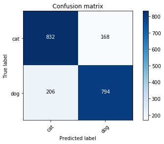

```
Testaccuracy: 0.813
```

```python
#load model
print('load model')
modelPath="Dogs-vs-Cats/trainResults/"
modelName='model_cnn_rgbs_batchnorm'
model = load_model(modelPath+modelName+'.h5')

#connect to image directory
print('load image')
imagePath="Dogs-vs-Cats/testDataSetScaled/"
files=os.listdir(imagePath)

#load means
with open("Dogs-vs-Cats/means.pickle", "rb") as input_file:
    means = pickle.load(input_file)

#classification parameter
dim=model.input.shape.as_list()
classes={'cat':0,'dog':1}

actualClasses=[]
predictedClasses=[]
diff=[]

#iterate image files
for file in tqdm(files):
    #load image
    img = imageio.imread(imagePath+file,as_gray=False)
    label = classes[file.split('(')[0]]

    #scale image
    img = cv2.resize(img, dsize=(dim[1],dim[2]), interpolation=cv2.INTER_CUBIC)
    img = np.reshape(img,[1,dim[1],dim[2],3])
    prediction = model.predict(img)

    actualClasses.append(label)
    predictedClasses.append(np.argmax(prediction))

#confusion matrix
conf=confusion_matrix(actualClasses, predictedClasses)

plt.figure()
plot_confusion_matrix(conf, classes=list(classes.keys()), title='Confusion matrix')
plt.savefig(modelPath+'_confMat_'+modelName)
plt.show()

#calculate test accuracy
diff=[1 if x[0]!=x[1] else 0 for x in zip(actualClasses,predictedClasses)]
print('Testaccuracy: {0}'.format(1-sum(diff)/len(diff)))
```

**CNN with RGB Scaled Images, Batch-Normalization, Dropout and L2-Regularization:**

```
Train on 16100 samples, validate on 6900 samples
Trainingduration: 0:09:45.712810
```

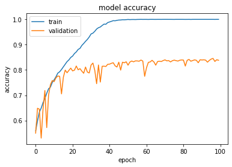

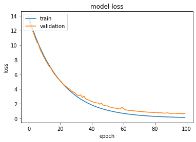

```python
#load data

dataDirectory="Dogs-vs-Cats/dataSetScaled/"
output="Dogs-vs-Cats/trainResults/"
modelName='model_cnn_rgbs_reg'

#manage directory
if not os.path.exists(output):
    os.makedirs(output)

#parameter
batchSize=128
epochs=100
validationSplit=0.30

features = dataDirectory+'data_s.npy'
X = np.load(features)

labels = dataDirectory+'labels_s.npy'
y = np.load(labels)

#%% Callbacks
callbacks=[]
callbacks.append(EarlyStopping(monitor='val_loss',patience=15,verbose=0, mode='auto'))
callbacks.append(ModelCheckpoint(output+modelName+'_check_.h5', save_best_only=True, monitor='val_loss', mode='min'))

seed = 7

#Split into train/test sets
X_train, X_val, y_train, y_val = train_test_split(X, y, test_size=validationSplit,random_state=seed,stratify=y)
steps_per_epoch=len(X_train)//batchSize

model=getCNN_reg(np.shape(X[0]),2)

#compile model

opt=optimizers.SGD(lr=0.001,momentum=0.9)
model.compile(optimizer=opt , loss='categorical_crossentropy', metrics=['accuracy'])

#Train Model
t = time.time()
hist = model.fit(X_train, y_train, batch_size=batchSize, epochs=epochs,validation_data=(X_val, y_val), callbacks=callbacks,verbose=1)

elapsed = time.time() - t
print('Trainingduration: '+str(datetime.timedelta(seconds=elapsed)))

#save model
model.save(output+modelName+'.h5')

#generate and save plots
# plot history for accuracy
plt.figure()
plt.ioff()
plt.plot(hist.history['accuracy'])
plt.plot(hist.history['val_accuracy'])
plt.title('model accuracy')
plt.ylabel('accuracy')
plt.xlabel('epoch')
plt.legend(['train', 'validation'], loc='upper left')
plt.savefig(output+'_accuracy_'+modelName)

# plot history for loss
plt.figure()
plt.ioff()
plt.plot(hist.history['loss'])
plt.plot(hist.history['val_loss'])
plt.title('model loss')
plt.ylabel('loss')
plt.xlabel('epoch')
plt.legend(['train', 'validation'], loc='upper left')
plt.savefig(output+'_loss_'+modelName)

#save detail information
with open(output+modelName+".txt","w+") as f:

    f.write('Trainparameter:\n')
    f.write('ValidationSplit: {0}\n'.format(validationSplit))
    f.write('Batchsize: {0}\n'.format(batchSize))
    f.write('Epochs: {0}\n'.format(epochs))
    f.write('Steps per epoch: {0}\n'.format(steps_per_epoch))
    f.write('Inputdimension:\n'+str(np.shape(X_train[0])))
    f.write('\n')
    f.write('Results:\n')
    f.write('Trainaccuracy: {0}\n'.format(hist.history['accuracy'][-1]*100))
    f.write('Validationaccuracy: {0}\n'.format(hist.history['val_accuracy'][-1]*100))
    f.write('Best Validation: {0}\n'.format(np.max(hist.history['val_accuracy'])*100))
    f.write('\n')
    f.write('Modelarchitecture:\n')
    with redirect_stdout(f):
        model.summary()
```

```
load model
```

```
load image
```

```
Confusion matrix, without normalization
[[855 145]
 [198 802]]
```

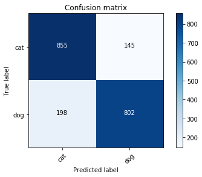

```
Testaccuracy: 0.8285
```

```python
#load model
print('load model')
modelPath="Dogs-vs-Cats/trainResults/"
modelName='model_cnn_rgbs_reg'
model = load_model(modelPath+modelName+'.h5')

#connect to image directory
print('load image')
imagePath="Dogs-vs-Cats/testDataSetScaled/"
files=os.listdir(imagePath)

#load means
with open("Dogs-vs-Cats/means.pickle", "rb") as input_file:
    means = pickle.load(input_file)

#classification parameter
dim=model.input.shape.as_list()
classes={'cat':0,'dog':1}

actualClasses=[]
predictedClasses=[]
diff=[]

#iterate image files
for file in tqdm(files):
    #load image
    img = imageio.imread(imagePath+file,as_gray=False)
    label = classes[file.split('(')[0]]

    #scale image
    img = cv2.resize(img, dsize=(dim[1],dim[2]), interpolation=cv2.INTER_CUBIC)
    img = np.reshape(img,[1,dim[1],dim[2],3])
    prediction = model.predict(img)

    actualClasses.append(label)
    predictedClasses.append(np.argmax(prediction))

#confusion matrix
conf=confusion_matrix(actualClasses, predictedClasses)

plt.figure()
plot_confusion_matrix(conf, classes=list(classes.keys()), title='Confusion matrix')
plt.savefig(modelPath+'_confMat_'+modelName)
plt.show()

#calculate test accuracy
diff=[1 if x[0]!=x[1] else 0 for x in zip(actualClasses,predictedClasses)]
print('Testaccuracy: {0}'.format(1-sum(diff)/len(diff)))
```

**ResNet with RGB Scaled Images:**

```
Train on 16100 samples, validate on 6900 samples
Trainingduration: 0:15:52.753283
```

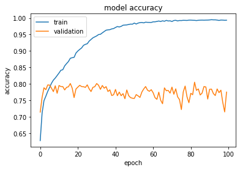

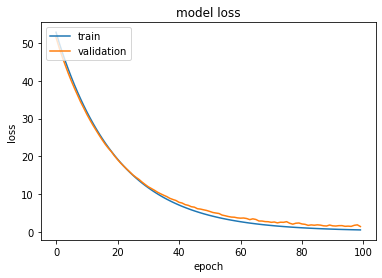

```python
#load data

dataDirectory="Dogs-vs-Cats/dataSetScaled/"
output="Dogs-vs-Cats/trainResults/"
modelName='model_cnn_rgbs_res'

#manage directory
if not os.path.exists(output):
    os.makedirs(output)

#parameter
batchSize=128
epochs=100
validationSplit=0.30

features = dataDirectory+'data_s.npy'
X = np.load(features)

labels = dataDirectory+'labels_s.npy'
y = np.load(labels)

#%% Callbacks
callbacks=[]
callbacks.append(EarlyStopping(monitor='val_loss',patience=15,verbose=0, mode='auto'))
callbacks.append(ModelCheckpoint(output+modelName+'_check_.h5', save_best_only=True, monitor='val_loss', mode='min'))

seed = 7

#Split into train/test sets
X_train, X_val, y_train, y_val = train_test_split(X, y, test_size=validationSplit,random_state=seed,stratify=y)
steps_per_epoch=len(X_train)//batchSize

model=getResnet(np.shape(X[0]),2)

#compile model

opt=optimizers.SGD(lr=0.001,momentum=0.9)
model.compile(optimizer=opt , loss='categorical_crossentropy', metrics=['accuracy'])

#Train Model
t = time.time()
hist = model.fit(X_train, y_train, batch_size=batchSize, epochs=epochs,validation_data=(X_val, y_val), callbacks=callbacks,verbose=1)

elapsed = time.time() - t
print('Trainingduration: '+str(datetime.timedelta(seconds=elapsed)))

#save model
model.save(output+modelName+'.h5')

#generate and save plots
# plot history for accuracy
plt.figure()
plt.ioff()
plt.plot(hist.history['accuracy'])
plt.plot(hist.history['val_accuracy'])
plt.title('model accuracy')
plt.ylabel('accuracy')
plt.xlabel('epoch')
plt.legend(['train', 'validation'], loc='upper left')
plt.savefig(output+'_accuracy_'+modelName)

# plot history for loss
plt.figure()
plt.ioff()
plt.plot(hist.history['loss'])
plt.plot(hist.history['val_loss'])
plt.title('model loss')
plt.ylabel('loss')
plt.xlabel('epoch')
plt.legend(['train', 'validation'], loc='upper left')
plt.savefig(output+'_loss_'+modelName)

#save detail information
with open(output+modelName+".txt","w+") as f:

    f.write('Trainparameter:\n')
    f.write('ValidationSplit: {0}\n'.format(validationSplit))
    f.write('Batchsize: {0}\n'.format(batchSize))
    f.write('Epochs: {0}\n'.format(epochs))
    f.write('Steps per epoch: {0}\n'.format(steps_per_epoch))
    f.write('Inputdimension:\n'+str(np.shape(X_train[0])))
    f.write('\n')
    f.write('Results:\n')
    f.write('Trainaccuracy: {0}\n'.format(hist.history['accuracy'][-1]*100))
    f.write('Validationaccuracy: {0}\n'.format(hist.history['val_accuracy'][-1]*100))
    f.write('Best Validation: {0}\n'.format(np.max(hist.history['val_accuracy'])*100))
    f.write('\n')
    f.write('Modelarchitecture:\n')
    with redirect_stdout(f):
        model.summary()
```

```
load model
```

```
load image
```

```
Confusion matrix, without normalization
[[645 355]
 [101 899]]
```

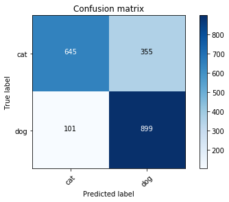

```
Testaccuracy: 0.772
```

```python
#load model
print('load model')
modelPath="Dogs-vs-Cats/trainResults/"
modelName='model_cnn_rgbs_res'
model = load_model(modelPath+modelName+'.h5')

#connect to image directory
print('load image')
imagePath="Dogs-vs-Cats/testDataSetScaled/"
files=os.listdir(imagePath)

#load means
with open("Dogs-vs-Cats/means.pickle", "rb") as input_file:
    means = pickle.load(input_file)

#classification parameter
dim=model.input.shape.as_list()
classes={'cat':0,'dog':1}

actualClasses=[]
predictedClasses=[]
diff=[]

#iterate image files
for file in tqdm(files):
    #load image
    img = imageio.imread(imagePath+file,as_gray=False)
    label = classes[file.split('(')[0]]

    #scale image
    img = cv2.resize(img, dsize=(dim[1],dim[2]), interpolation=cv2.INTER_CUBIC)
    img = np.reshape(img,[1,dim[1],dim[2],3])
    prediction = model.predict(img)

    actualClasses.append(label)
    predictedClasses.append(np.argmax(prediction))

#confusion matrix
conf=confusion_matrix(actualClasses, predictedClasses)

plt.figure()
plot_confusion_matrix(conf, classes=list(classes.keys()), title='Confusion matrix')
plt.savefig(modelPath+'_confMat_'+modelName)
plt.show()

#calculate test accuracy
diff=[1 if x[0]!=x[1] else 0 for x in zip(actualClasses,predictedClasses)]
print('Testaccuracy: {0}'.format(1-sum(diff)/len(diff)))
```

**VGG16 with RGB Scaled Images:**

```
Train on 16100 samples, validate on 6900 samples
Trainingduration: 0:03:41.619975
```

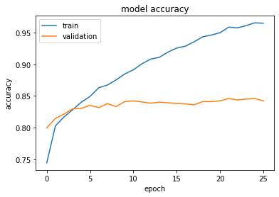

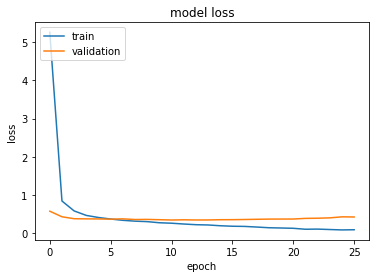

```python
#load data

dataDirectory="Dogs-vs-Cats/dataSetScaled/"
output="Dogs-vs-Cats/trainResults/"
modelName='model_cnn_rgbs_vgg'

#manage directory
if not os.path.exists(output):
    os.makedirs(output)

#parameter
batchSize=128
epochs=100
validationSplit=0.30

features = dataDirectory+'data_s.npy'
X = np.load(features)

labels = dataDirectory+'labels_s.npy'
y = np.load(labels)

#%% Callbacks
callbacks=[]
callbacks.append(EarlyStopping(monitor='val_loss',patience=15,verbose=0, mode='auto'))
callbacks.append(ModelCheckpoint(output+modelName+'_check_.h5', save_best_only=True, monitor='val_loss', mode='min'))

seed = 7

#Split into train/test sets
X_train, X_val, y_train, y_val = train_test_split(X, y, test_size=validationSplit,random_state=seed,stratify=y)
steps_per_epoch=len(X_train)//batchSize

model=vgg16(np.shape(X[0]),2)

#compile model

opt=optimizers.SGD(lr=0.001,momentum=0.9)
model.compile(optimizer=opt , loss='categorical_crossentropy', metrics=['accuracy'])

#Train Model
t = time.time()
hist = model.fit(X_train, y_train, batch_size=batchSize, epochs=epochs,validation_data=(X_val, y_val), callbacks=callbacks,verbose=1)

elapsed = time.time() - t
print('Trainingduration: '+str(datetime.timedelta(seconds=elapsed)))

#save model
model.save(output+modelName+'.h5')

#generate and save plots
# plot history for accuracy
plt.figure()
plt.ioff()
plt.plot(hist.history['accuracy'])
plt.plot(hist.history['val_accuracy'])
plt.title('model accuracy')
plt.ylabel('accuracy')
plt.xlabel('epoch')
plt.legend(['train', 'validation'], loc='upper left')
plt.savefig(output+'_accuracy_'+modelName)

# plot history for loss
plt.figure()
plt.ioff()
plt.plot(hist.history['loss'])
plt.plot(hist.history['val_loss'])
plt.title('model loss')
plt.ylabel('loss')
plt.xlabel('epoch')
plt.legend(['train', 'validation'], loc='upper left')
plt.savefig(output+'_loss_'+modelName)

#save detail information
with open(output+modelName+".txt","w+") as f:

    f.write('Trainparameter:\n')
    f.write('ValidationSplit: {0}\n'.format(validationSplit))
    f.write('Batchsize: {0}\n'.format(batchSize))
    f.write('Epochs: {0}\n'.format(epochs))
    f.write('Steps per epoch: {0}\n'.format(steps_per_epoch))
    f.write('Inputdimension:\n'+str(np.shape(X_train[0])))
    f.write('\n')
    f.write('Results:\n')
    f.write('Trainaccuracy: {0}\n'.format(hist.history['accuracy'][-1]*100))
    f.write('Validationaccuracy: {0}\n'.format(hist.history['val_accuracy'][-1]*100))
    f.write('Best Validation: {0}\n'.format(np.max(hist.history['val_accuracy'])*100))
    f.write('\n')
    f.write('Modelarchitecture:\n')
    with redirect_stdout(f):
        model.summary()
```

```
load model
```

```
load image
```

```
Confusion matrix, without normalization
[[841 159]
 [154 846]]
```

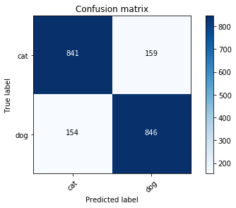

```
Testaccuracy: 0.8435
```

```python
#load model
print('load model')
modelPath="Dogs-vs-Cats/trainResults/"
modelName='model_cnn_rgbs_vgg'
model = load_model(modelPath+modelName+'.h5')

#connect to image directory
print('load image')
imagePath="Dogs-vs-Cats/testDataSetScaled/"
files=os.listdir(imagePath)

#load means
with open("Dogs-vs-Cats/means.pickle", "rb") as input_file:
    means = pickle.load(input_file)

#classification parameter
dim=model.input.shape.as_list()
classes={'cat':0,'dog':1}

actualClasses=[]
predictedClasses=[]
diff=[]

#iterate image files
for file in tqdm(files):
    #load image
    img = imageio.imread(imagePath+file,as_gray=False)
    label = classes[file.split('(')[0]]

    #scale image
    img = cv2.resize(img, dsize=(dim[1],dim[2]), interpolation=cv2.INTER_CUBIC)
    img = np.reshape(img,[1,dim[1],dim[2],3])
    prediction = model.predict(img)

    actualClasses.append(label)
    predictedClasses.append(np.argmax(prediction))

#confusion matrix
conf=confusion_matrix(actualClasses, predictedClasses)

plt.figure()
plot_confusion_matrix(conf, classes=list(classes.keys()), title='Confusion matrix')
plt.savefig(modelPath+'_confMat_'+modelName)
plt.show()

#calculate test accuracy
diff=[1 if x[0]!=x[1] else 0 for x in zip(actualClasses,predictedClasses)]
print('Testaccuracy: {0}'.format(1-sum(diff)/len(diff)))
```

**VGG16 with RGB Scaled Images and Fine Tuning:**

```
Train on 16100 samples, validate on 6900 samples
Trainingduration: 0:18:27.692058
```

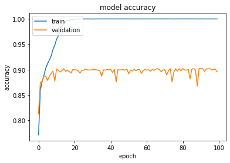

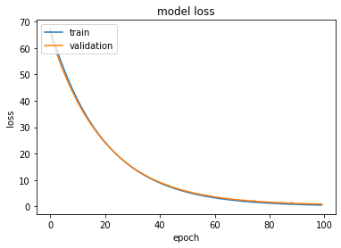

```python
#load data

dataDirectory="Dogs-vs-Cats/dataSetScaled/"
output="Dogs-vs-Cats/trainResults/"
modelName='model_cnn_rgbs_vgg2'

#manage directory
if not os.path.exists(output):
    os.makedirs(output)

#parameter
batchSize=128
epochs=100
validationSplit=0.30

features = dataDirectory+'data_s.npy'
X = np.load(features)

labels = dataDirectory+'labels_s.npy'
y = np.load(labels)

#%% Callbacks
callbacks=[]
callbacks.append(EarlyStopping(monitor='val_loss',patience=15,verbose=0, mode='auto'))
callbacks.append(ModelCheckpoint(output+modelName+'_check_.h5', save_best_only=True, monitor='val_loss', mode='min'))

seed = 7

#Split into train/test sets
X_train, X_val, y_train, y_val = train_test_split(X, y, test_size=validationSplit,random_state=seed,stratify=y)
steps_per_epoch=len(X_train)//batchSize

model=vgg16v2(np.shape(X[0]),2)

#compile model

opt=optimizers.SGD(lr=0.001,momentum=0.9)
model.compile(optimizer=opt , loss='categorical_crossentropy', metrics=['accuracy'])

#Train Model
t = time.time()
hist = model.fit(X_train, y_train, batch_size=batchSize, epochs=epochs,validation_data=(X_val, y_val), callbacks=callbacks,verbose=1)

elapsed = time.time() - t
print('Trainingduration: '+str(datetime.timedelta(seconds=elapsed)))

#save model
model.save(output+modelName+'.h5')

#generate and save plots
# plot history for accuracy
plt.figure()
plt.ioff()
plt.plot(hist.history['accuracy'])
plt.plot(hist.history['val_accuracy'])
plt.title('model accuracy')
plt.ylabel('accuracy')
plt.xlabel('epoch')
plt.legend(['train', 'validation'], loc='upper left')
plt.savefig(output+'_accuracy_'+modelName)

# plot history for loss
plt.figure()
plt.ioff()
plt.plot(hist.history['loss'])
plt.plot(hist.history['val_loss'])
plt.title('model loss')
plt.ylabel('loss')
plt.xlabel('epoch')
plt.legend(['train', 'validation'], loc='upper left')
plt.savefig(output+'_loss_'+modelName)

#save detail information
with open(output+modelName+".txt","w+") as f:

    f.write('Trainparameter:\n')
    f.write('ValidationSplit: {0}\n'.format(validationSplit))
    f.write('Batchsize: {0}\n'.format(batchSize))
    f.write('Epochs: {0}\n'.format(epochs))
    f.write('Steps per epoch: {0}\n'.format(steps_per_epoch))
    f.write('Inputdimension:\n'+str(np.shape(X_train[0])))
    f.write('\n')
    f.write('Results:\n')
    f.write('Trainaccuracy: {0}\n'.format(hist.history['accuracy'][-1]*100))
    f.write('Validationaccuracy: {0}\n'.format(hist.history['val_accuracy'][-1]*100))
    f.write('Best Validation: {0}\n'.format(np.max(hist.history['val_accuracy'])*100))
    f.write('\n')
    f.write('Modelarchitecture:\n')
    with redirect_stdout(f):
        model.summary()
```

```
load model
```

```
load image
```

```
Confusion matrix, without normalization
[[836 164]
 [ 78 922]]
```

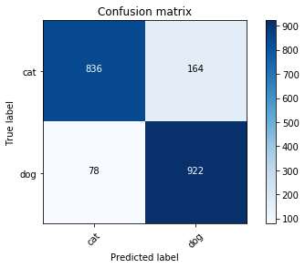

```
Testaccuracy: 0.879
```

```python
#load model
print('load model')
modelPath="Dogs-vs-Cats/trainResults/"
modelName='model_cnn_rgbs_vgg2'
model = load_model(modelPath+modelName+'.h5')

#connect to image directory
print('load image')
imagePath="Dogs-vs-Cats/testDataSetScaled/"
files=os.listdir(imagePath)

#load means
with open("Dogs-vs-Cats/means.pickle", "rb") as input_file:
    means = pickle.load(input_file)

#classification parameter
dim=model.input.shape.as_list()
classes={'cat':0,'dog':1}

actualClasses=[]
predictedClasses=[]
diff=[]

#iterate image files
for file in tqdm(files):
    #load image
    img = imageio.imread(imagePath+file,as_gray=False)
    label = classes[file.split('(')[0]]

    #scale image
    img = cv2.resize(img, dsize=(dim[1],dim[2]), interpolation=cv2.INTER_CUBIC)
    img = np.reshape(img,[1,dim[1],dim[2],3])
    prediction = model.predict(img)

    actualClasses.append(label)
    predictedClasses.append(np.argmax(prediction))

#confusion matrix
conf=confusion_matrix(actualClasses, predictedClasses)

plt.figure()
plot_confusion_matrix(conf, classes=list(classes.keys()), title='Confusion matrix')
plt.savefig(modelPath+'_confMat_'+modelName)
plt.show()

#calculate test accuracy
diff=[1 if x[0]!=x[1] else 0 for x in zip(actualClasses,predictedClasses)]
print('Testaccuracy: {0}'.format(1-sum(diff)/len(diff)))
```

**VGG16 with RGB Scaled Images, Data Augmentation and Fine Tuning:**

```
WARNING:tensorflow:From <ipython-input-6-9eb8d478c701>:51: Model.fit_generator (from tensorflow.python.keras.engine.training) is deprecated and will be removed in a future version.
Instructions for updating:
Please use Model.fit, which supports generators.
WARNING:tensorflow:sample_weight modes were coerced from
  ...
    to
  ['...']
Train for 251 steps, validate on 6900 samples
Trainingduration: 0:30:49.108249
```

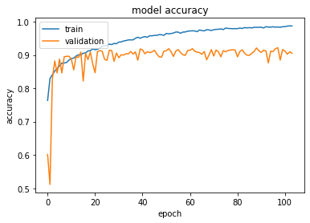

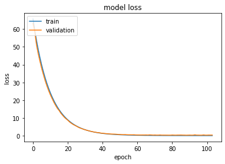

```python
#load data

dataDirectory="Dogs-vs-Cats/dataSetScaled/"
output="Dogs-vs-Cats/trainResults/"
modelName='model_cnn_rgbs_vgg2_aug'

#manage directory
if not os.path.exists(output):
    os.makedirs(output)

#parameter
batchSize=64
epochs=200
validationSplit=0.30

features = dataDirectory+'data_s.npy'
X = np.load(features)

labels = dataDirectory+'labels_s.npy'
y = np.load(labels)

#%% Callbacks
callbacks=[]
callbacks.append(EarlyStopping(monitor='val_loss',patience=15,verbose=0, mode='auto'))
callbacks.append(ModelCheckpoint(output+modelName+'_check_.h5', save_best_only=True, monitor='val_loss', mode='min'))

seed = 7

#Split into train/test sets
X_train, X_val, y_train, y_val = train_test_split(X, y, test_size=validationSplit,random_state=seed,stratify=y)
steps_per_epoch=len(X_train)//batchSize

model=vgg16v2(np.shape(X[0]),2)

#compile model

opt=optimizers.SGD(lr=0.001,momentum=0.9)
model.compile(optimizer=opt , loss='categorical_crossentropy', metrics=['accuracy'])

#data augmentation
aug = ImageDataGenerator(
        rotation_range=10,  # rotate in degrees
        zoom_range = 0.1, # zoom
        width_shift_range=0.2,  # shift images horizontally
        height_shift_range=0.2,  # shift images vertically
        horizontal_flip=True,  # flip images
        vertical_flip=False)  # flip images

#Train Model
t = time.time()
hist = model.fit_generator(aug.flow(X_train, y_train, batch_size=batchSize), validation_data=(X_val, y_val), steps_per_epoch=steps_per_epoch, epochs=epochs, callbacks=callbacks, verbose=1)

elapsed = time.time() - t
print('Trainingduration: '+str(datetime.timedelta(seconds=elapsed)))

#save model
model.save(output+modelName+'.h5')

#generate and save plots
# plot history for accuracy
plt.figure()
plt.ioff()
plt.plot(hist.history['accuracy'])
plt.plot(hist.history['val_accuracy'])
plt.title('model accuracy')
plt.ylabel('accuracy')
plt.xlabel('epoch')
plt.legend(['train', 'validation'], loc='upper left')
plt.savefig(output+'_accuracy_'+modelName)

# plot history for loss
plt.figure()
plt.ioff()
plt.plot(hist.history['loss'])
plt.plot(hist.history['val_loss'])
plt.title('model loss')
plt.ylabel('loss')
plt.xlabel('epoch')
plt.legend(['train', 'validation'], loc='upper left')
plt.savefig(output+'_loss_'+modelName)

#save detail information
with open(output+modelName+".txt","w+") as f:

    f.write('Trainparameter:\n')
    f.write('ValidationSplit: {0}\n'.format(validationSplit))
    f.write('Batchsize: {0}\n'.format(batchSize))
    f.write('Epochs: {0}\n'.format(epochs))
    f.write('Steps per epoch: {0}\n'.format(steps_per_epoch))
    f.write('Inputdimension:\n'+str(np.shape(X_train[0])))
    f.write('\n')
    f.write('Results:\n')
    f.write('Trainaccuracy: {0}\n'.format(hist.history['accuracy'][-1]*100))
    f.write('Validationaccuracy: {0}\n'.format(hist.history['val_accuracy'][-1]*100))
    f.write('Best Validation: {0}\n'.format(np.max(hist.history['val_accuracy'])*100))
    f.write('\n')
    f.write('Modelarchitecture:\n')
    with redirect_stdout(f):
        model.summary()
```

```
load model
```

```
load image
```

```
Confusion matrix, without normalization
[[860 140]
 [ 54 946]]
```

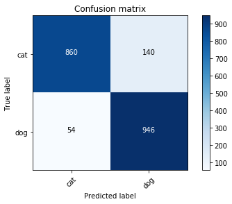

```
Testaccuracy: 0.903
```

```python
#load model
print('load model')
modelPath="Dogs-vs-Cats/trainResults/"
modelName='model_cnn_rgbs_vgg2_aug'
model = load_model(modelPath+modelName+'.h5')

#connect to image directory
print('load image')
imagePath="Dogs-vs-Cats/testDataSetScaled/"
files=os.listdir(imagePath)

#load means
with open("Dogs-vs-Cats/means.pickle", "rb") as input_file:
    means = pickle.load(input_file)

#classification parameter
dim=model.input.shape.as_list()
classes={'cat':0,'dog':1}

actualClasses=[]
predictedClasses=[]
diff=[]

#iterate image files
for file in tqdm(files):
    #load image
    img = imageio.imread(imagePath+file,as_gray=False)
    label = classes[file.split('(')[0]]

    #scale image
    img = cv2.resize(img, dsize=(dim[1],dim[2]), interpolation=cv2.INTER_CUBIC)
    img = np.reshape(img,[1,dim[1],dim[2],3])
    prediction = model.predict(img)

    actualClasses.append(label)
    predictedClasses.append(np.argmax(prediction))

#confusion matrix
conf=confusion_matrix(actualClasses, predictedClasses)

plt.figure()
plot_confusion_matrix(conf, classes=list(classes.keys()), title='Confusion matrix')
plt.savefig(modelPath+'_confMat_'+modelName)
plt.show()

#calculate test accuracy
diff=[1 if x[0]!=x[1] else 0 for x in zip(actualClasses,predictedClasses)]
print('Testaccuracy: {0}'.format(1-sum(diff)/len(diff)))
```